# Project 4 - Write a Data Science Blog Post

## Introduction

This project is part of the Udacity Become a Data Scientist Nanodegree. The task is to take one or more datasets, ask 3-5 questions that you then seek to answer following the CRISP-DM. The questions have to be answered using statistical analysis and if necessary machine learning algorithms. After the analysis the results shall be published in form of a blogpost on a website like Medium.

This notebook is structured roughly similar to the CRISP-DM. In the first few sections I'll be trying to develop a business and data understanding. Next, I'll prepare the data for analysis. And the last part is the actual analysis. Usually in the CRISP-DM, expecially when using machine learning, you divide it into "modelling", "evaluation" and "deployment". In this notebook these steps are somewhat mixed. In trying to analyse a certain part of the data, I've tried to set up the methods and procedures that would allow me to do so. During this process, I've tried different methods and regularly updated the methods or even went back to data-preparation to improve on the analysis. The deployment itself can be seen as the final analysis and the blogpost itself. I've not marked every iteration of this process, as this would make the notebook rather messy, but you can still see some iterations such as further aggregating regions after realising the first aggregation resulted in chaotic graphics for the analysis.

As for the data to analyse I followed the suggestion in the project outline and used the yearly StackOverflow survey, the datasets can be found here: https://insights.stackoverflow.com/survey. The results are also available in the subdirectory of this repository named "Data".

## Developing a Business (and Data) Understanding

The tricky thing with a project like this is, that you don't start your exploration with a question in mind. You are given the dataset and based on that you have to then find a few questions to ask. Thus, the first step is to get a feeling for the data you are given and understand what information you have to work with. Then you can start to formulate questions and create knowledge. Looking at the CRISP-DM structure, I'll be ping-ponging between Business and Data Understanding in the first few steps in an attempt to develop a business understanding. I might also have to delve into data preparation tasks early on to properly understand the data.

For this project I chose to analyze the results of the yearly Stackoverflow surveys, going back to the year 2011. Let's take a look and get a first impression on the data.

```python
# imports

import pandas as pd
import numpy as np
import matplotlib.pyplot as plt
```

```python
survey_years = [2011, 2012, 2013, 2014, 2015, 2016, 2017, 2018]
```

```python
# load in the datasets
survey_results = {
    2011: pd.read_csv('Data/2011_Stack_Overflow_Survey_Results.csv', engine='python'),
    2012: pd.read_csv('Data/2012_Stack_Overflow_Survey_Results.csv', engine='python'),
    2013: pd.read_csv('Data/2013_Stack_Overflow_Survey_Results.csv', engine='python'),
    2014: pd.read_csv('Data/2014_Stack_Overflow_Survey_Results.csv', engine='python'),
    2015: pd.read_csv('Data/2015_Stack_Overflow_Survey_Results.csv', engine='python'),
    2016: pd.read_csv('Data/2016_Stack_Overflow_Survey_Results.csv', engine='python'),
    2017: pd.read_csv('Data/2017_Stack_Overflow_Survey_Results.csv', engine='python'),
    2018: pd.read_csv('Data/2018_Stack_Overflow_Survey_Results.csv', engine='python')
}
survey_schemas = {
    2017: pd.read_csv('Data/2017_Stack_Overflow_Survey_Schema.csv', engine='python'),
    2018: pd.read_csv('Data/2018_Stack_Overflow_Survey_Schema.csv', engine='python')
}
```

```python
survey_results[2011].head()
```

|  | What Country or Region do you live in? | Which US State or Territory do you live in? | How old are you? | How many years of IT/Programming experience do you have? | How would you best describe the industry you work in? | Which best describes the size of your company? | Which of the following best describes your occupation? | How likely is it that a recommendation you make will be acted upon? | What is your involvement in purchasing? You can choose more than 1. | Unnamed: 9 | ... | Unnamed: 55 | Unnamed: 56 | Unnamed: 57 | Unnamed: 58 | Unnamed: 59 | Unnamed: 60 | Unnamed: 61 | Unnamed: 62 | In the last 12 months, how much money have you spent on personal technology-related purchases? | Which of our sites do you frequent most? |
| --- | --- | --- | --- | --- | --- | --- | --- | --- | --- | --- | --- | --- | --- | --- | --- | --- | --- | --- | --- | --- | --- |
| 0 | Response | Response | Response | Response | Response | Response | Response | Response | Influencer | Recommender | ... | AppleTV | iPad | Other netbook | PS3 | Xbox | Wii | Other gaming system | other (please specify) | Response | Response |
| 1 | Africa | NaN | < 20 | <2 | Consulting | Start Up (1-25) | Web Application Developer | Not in a million years | NaN | NaN | ... | NaN | NaN | NaN | NaN | NaN | NaN | NaN | NaN | <$100 | NaN |
| 2 | Other Europe | NaN | 25-29 | 41310 | Software Products | Mature Small Business (25-100) | Server Programmer | It's been known to happen | NaN | NaN | ... | NaN | NaN | Other netbook | NaN | NaN | NaN | NaN | NaN | $251-$500 | Stack Overflow |
| 3 | India | NaN | 25-29 | 41435 | Software Products | Mid Sized (100-999) | Server Programmer | Unless it's stoopid it gets done | NaN | NaN | ... | NaN | NaN | NaN | NaN | NaN | NaN | NaN | NaN | NaN | NaN |
| 4 | Germany | NaN | < 20 | 41310 | Foundation / Non-Profit | Student | Student | It's been known to happen | NaN | NaN | ... | NaN | NaN | NaN | NaN | NaN | Wii | Other gaming system | NaN | $501-$1,000 | Stack Overflow |

5 rows × 65 columns

The first observation is that there is a large number of columns with the label "Unnamed". No schema is provided with the dataset. One option is to drop the unnamed columns, though they could provide interesting insights. Maybe there is a way to recreate a label of the column based on the answers (samples). Additionally, the other column labels are long questions rather than a short label.

The second observation is that the first row seems to give additional information on the column rather than being the first set of survey answers.

Maybe there is a way to define short labels for all columns based on the question in the current label, the first row and the answers in the other rows.

Time to skip through all the columns and find an appropriate label...

```python
def print_col_info(df, col = 0):
    if CURRENT_COLUMN >= df.shape[1]:
        print('-' * 50)
        print('That was the last column.')
        print('-' * 50)
        return
    print('-' * 50)
    print('Column {} of {}'.format(CURRENT_COLUMN, df.shape[1]))
    print('-' * 50)
    print('Current Label: --------- {}'.format(df.columns[col]))
    print('1st Row: --------------- {}'.format(df.iloc[0,col]))
    print('-' * 50)
    print(df.iloc[:,col].value_counts())
    print('-' * 50)
```

```python
CURRENT_COLUMN = -1
```

```python
CURRENT_COLUMN += 1
print_col_info(survey_results[2011], col = CURRENT_COLUMN)
```

```
--------------------------------------------------
Column 0 of 65
--------------------------------------------------
Current Label: --------- What Country or Region do you live in?
1st Row: --------------- Response
--------------------------------------------------
United States of America    1037
Other Europe                 451
United Kingdom               314
Canada                       156
Australia                    112
Germany                      106
India                         95
South America                 91
Other Asia                    81
Middle East                   73
France                        60
Netherlands                   55
Africa                        43
Russia                        41
Italy                         35
Australasia                   29
Mexico                        20
North America (Other)          8
Central America                6
Response                       1
Name: What Country or Region do you live in?, dtype: int64
--------------------------------------------------
```

```python
CURRENT_COLUMN -= 1
print_col_info(survey_results[2011], col = CURRENT_COLUMN)
```

```
--------------------------------------------------
Column -1 of 65
--------------------------------------------------
Current Label: --------- Which of our sites do you frequent most?
1st Row: --------------- Response
--------------------------------------------------
Stack Overflow                2230
Programmers Stack Exchange      82
Other                           76
Super User                      57
Server Fault                    56
Meta Stack Overflow             17
None                            14
Response                         1
Name: Which of our sites do you frequent most?, dtype: int64
--------------------------------------------------
```

And now let's update the labels. To do so let's create a dictionary with all the proper labels and apply it to every year's survey.

```python
survey_labels = {year: list() for year in survey_years}
```

```python
survey_labels[2011] = ['Country', 'US_State', 'Age', 'IT_Experience', 'Industry', 'Company_Size', 'Occupation',
                       'Influence', 'Purchase_Involvement_Influencer', 'Purchase_Involvement_Recommender',
                       'Purchase_Involvement_Approver', 'Purchase_Involvement_Purchaser', 'Purchase_Involvement_Check_Writer',
                       'Purchase_Involvement_None', 'Purchase_Involvement_Seller', 'Purchase_Types_Hardware',
                       'Purchase_Types_Servers', 'Purchase_Types_Software', 'Purchase_Types_User_Equipment',
                       'Purchase_Types_Consultants', 'Purchase_Types_Other', 'Budget_less_than_10k', 'Budget_10k_to_25k',
                       'Budget_25k_to_40k', 'Budget_40k_to_75k', 'Budget_75k_to_100k', 'Budget_100k_to_150k',
                       'Budget_more_than_150k', 'Budget_Unsure', 'Project_Type', 'Lang_Tech_Used_Java',
                       'Lang_Tech_Used_JavaScript', 'Lang_Tech_Used_CSS', 'Lang_Tech_Used_PHP', 'Lang_Tech_Used_Python',
                       'Lang_Tech_Used_Ruby', 'Lang_Tech_Used_SQL', 'Lang_Tech_Used_C#', 'Lang_Tech_Used_C++',
                       'Lang_Tech_Used_C', 'Lang_Tech_Used_Perl', 'Lang_Tech_Used_None', 'Lang_Tech_Used_Other',
                       'Operating_System', 'Job_Satisfaction', 'Salary', 'Ownership_iPhone', 'Ownership_Android',
                       'Ownership_Blackberry', 'Ownership_Other_Smartphone', 'Ownership_Regular_Mobile_Phone',
                       'Ownership_Kindle', 'Ownership_Nook', 'Ownership_Blue-Ray', 'Ownership_HDTV', 'Ownership_AppleTV',
                       'Ownership_iPad', 'Ownership_Other_Netbook', 'Ownership_PS3', 'Ownership_Xbox', 'Ownership_Wii',
                       'Ownership_Other_Gaming', 'Ownership_Other', 'Expenditure_Tech', 'Most_Frequent_Site']
survey_labels[2012] = ['Country', 'US_State', 'Age', 'IT_Experience', 'Industry', 'Company_Size', 'Occupation',
                       'Purchase_Involvement_Influencer', 'Purchase_Involvement_Recommender', 'Purchase_Involvement_Approver',
                       'Purchase_Involvement_Purchaser', 'Purchase_Involvement_Check_Writer', 'Purchase_Involvement_None',
                       'Purchase_Involvement_Seller', 'Purchase_Types_Hardware', 'Purchase_Types_Servers',
                       'Purchase_Types_Software', 'Purchase_Types_User_Equipment', 'Purchase_Types_Consultants',
                       'Purchase_Types_Other', 'Budget', 'Project_Type', 'Lang_Tech_Used_Java', 'Lang_Tech_Used_JavaScript',
                       'Lang_Tech_Used_CSS', 'Lang_Tech_Used_PHP', 'Lang_Tech_Used_Python', 'Lang_Tech_Used_Objective-C',
                       'Lang_Tech_Used_Ruby', 'Lang_Tech_Used_SQL', 'Lang_Tech_Used_C#', 'Lang_Tech_Used_C++',
                       'Lang_Tech_Used_C', 'Lang_Tech_Used_Perl', 'Lang_Tech_Used_HTML5', 'Lang_Tech_Used_None',
                       'Lang_Tech_Used_Other', 'Operating_System', 'Job_Satisfaction', 'Salary', 'Stack_Overflow_Careers_Known',
                       'Stack_Overflow_Careers_Profile', 'Stack_Overflow_Careers_If_No_Profile',
                       'Stack_Overflow_Careers_If_No_Profile_Other', 'Ownership_iPhone', 'Ownership_Android',
                       'Ownership_Blackberry',  'Ownership_Windows_Phone', 'Ownership_Other_Smartphone',
                       'Ownership_Regular_Mobile_Phone', 'Ownership_Kindle', 'Ownership_Nook', 'Ownership_AppleTV',
                       'Ownership_Boxee', 'Ownership_Other_Streaming', 'Ownership_Netbook',  'Ownership_PS3',
                       'Ownership_Xbox', 'Ownership_Wii', 'Ownership_Other_Gaming', 'Ownership_Kindle_Fire',
                       'Ownership_iPad', 'Ownership_Other_Tablet', 'Ownership_Other', 'Expenditure_Tech',
                       'Advertising_Relevant', 'Advertising_Entertaining', 'Advertising_Informative',
                       'Advertising_Click_Interesting', 'Advertising_Result_Purchase',
                       'Advertising_Use_AdBlock', 'Advertising_Advertisers_Seen', 'Stack_Overflow_Reputation',
                       'Most_Frequent_Site', 'Other_Stack_Exchange']
survey_labels[2013] = ['Country', 'US_State', 'Age', 'IT_Experience', 'Industry', 'Company_Size', 'Occupation',
                       'Developers_Employed', 'Team_Size', 'Interaction_With_System_Admins', 'Interaction_With_Designers',
                       'Interaction_With_Product_Managers', 'Interaction_With_Testers_QA', 'Interaction_With_Tech_Support',
                       'Interaction_With_Sales_Marketing', 'Interaction_With_Consultants', 'Interaction_With_Customers',
                       'Interaction_With_Finance', 'Interaction_With_HR', 'Company_App_iPhone', 'Company_App_iPad',
                       'Company_App_Android_phone', 'Company_App_Android_tablet', 'Company_App_Blackberry', 'Company_App_Other',
                       'Company_App_No_App', 'Revenue_Advertising', 'Revenue_Direct_Sales_B2C', 'Revenue_Direct_Sales_B2B',
                       'Revenue_SaaS', 'Revenue_Mobile_App', 'Revenue_Consulting', 'Revenue_Fund_raising', 'Revenue_Other',
                       'Time_Allocation_New_Features', 'Time_Allocation_Refactoring', 'Time_Allocation_Bug_Fixing',
                       'Time_Allocation_Tech_Support', 'Time_Allocation_Meetings', 'Time_Allocation_Studying',
                       'Time_Allocation_Browsing', 'Time_Allocation_Commuting', 'Purchase_Involvement_Recommender',
                       'Purchase_Involvement_Influencer',  'Purchase_Involvement_Purchaser_Limited',
                       'Purchase_Involvement_Purchaser_Unlimited', 'Purchase_Involvement_Check_Writer',
                       'Purchase_Involvement_None', 'Purchase_Involvement_Seller', 'Purchase_Types_Hardware',
                       'Purchase_Types_Servers', 'Purchase_Types_Software', 'Purchase_Types_User_Equipment',
                       'Purchase_Types_Consultants', 'Purchase_Types_Other', 'Budget', 'Lang_Tech_Used_C',
                       'Lang_Tech_Used_C++', 'Lang_Tech_Used_C#', 'Lang_Tech_Used_Java', 'Lang_Tech_Used_JavaScript',
                       'Lang_Tech_Used_jQuery', 'Lang_Tech_Used_JQuery', 'Lang_Tech_Used_NodeJS', 'Lang_Tech_Used_Objective_C',
                       'Lang_Tech_Used_PHP', 'Lang_Tech_Used_Python', 'Lang_Tech_Used_Ruby', 'Lang_Tech_Used_SQL',
                       'Lang_Tech_Used_Other', 'Excited_NodeJS', 'Excited_Haskell', 'Excited_CoffeeScript', 'Excited_Dart',
                       'Excited_TypeScript', 'Excited_C++11', 'Excited_WinRT', 'Excited_Redis', 'Excited_MongoDB',
                       'Excited_F#', 'Excited_PhoneGap', 'Operating_System', 'Non_Negotiables_High_Compensation',
                       'Non_Negotiables_Profit_Sharing', 'Non_Negotiables_Identification', 'Non_Negotiables_Product_Excitement',
                       'Non_Negotiables_New_Tech', 'Non_Negotiables_Skill_Growth', 'Non_Negotiables_Offices',
                       'Non_Negotiables_Smart_Team', 'Non_Negotiables_Positive_Structure', 'Non_Negotiables_Task_Autonomy',
                       'Non_Negotiables_Workstation', 'Non_Negotiables_Budget_Autonomy', 'Non_Negotiables_Location',
                       'Non_Negotiables_Commute_Options', 'Non_Negotiables_40_hour', 'Non_Negotiables_Limited_Offhour',
                       'Recent_Job_Change', 'Job_Satisfaction', 'Salary', 'Ownership_iPhone', 'Ownership_Android',
                       'Ownership_Blackberry',  'Ownership_Windows_Phone', 'Ownership_iPad', 'Ownership_Android_tablet',
                       'Ownership_Kindle_Fire', 'Ownership_Windows_tablet', 'Ownership_Kindle', 'Ownership_Nook',
                       'Ownership_PS3', 'Ownership_Xbox', 'Ownership_Wii', 'Ownership_Other', 'Expenditure_Tech',
                       'Advertising_Relevant', 'Advertising_Entertaining', 'Advertising_Informative',
                       'Advertising_Click_Interesting', 'Advertising_Result_Purchase', 'Advertising_Use_AdBlock',
                       'Advertising_Advertisers_Seen', 'Stack_Overflow_Reputation', 'SO_Usage_Read_Answers',
                       'SO_Usage_Write_Questions', 'SO_Usage_Answer_Questions', 'SO_Usage_Other']
survey_labels[2014] = ['Country', 'Country_Other', 'US_State', 'Age', 'Gender', 'IT_Experience', 'Occupation', 'Salary',
                       'Industry', 'Developers_Employed', 'Remote_Work_Frequency', 'Remote_Work_Preference',
                       'Remote_Work_Location', 'Company_App_iPhone', 'Company_App_iPad', 'Company_App_Android_phone',
                       'Company_App_Android_tablet', 'Company_App_Windows_Phone', 'Company_App_Other', 'Company_App_No_App',
                       'Time_Allocation_New_Features', 'Time_Allocation_Refactoring', 'Time_Allocation_Bug_Fixing',
                       'Time_Allocation_Tech_Support', 'Time_Allocation_Meetings', 'Time_Allocation_Studying',
                       'Time_Allocation_Browsing', 'Time_Allocation_Job_Search', 'Time_Allocation_Stack_Exchange',
                       'Purchase_Involvement_Recommender', 'Purchase_Involvement_Influencer',
                       'Purchase_Involvement_Purchaser_Limited',  'Purchase_Involvement_Purchaser_Unlimited',
                       'Purchase_Involvement_None', 'Purchase_Types_Hardware', 'Purchase_Types_Servers',
                       'Purchase_Types_Software', 'Purchase_Types_User_Equipment', 'Purchase_Types_Consultants',
                       'Purchase_Types_Recruitment_Tools', 'Purchase_Types_Other', 'Budget', 'Lang_Tech_Used_C',
                       'Lang_Tech_Used_C++', 'Lang_Tech_Used_C#', 'Lang_Tech_Used_Java', 'Lang_Tech_Used_JavaScript',
                       'Lang_Tech_Used_NodeJS', 'Lang_Tech_Used_Objective_C', 'Lang_Tech_Used_PHP', 'Lang_Tech_Used_Python',
                       'Lang_Tech_Used_Ruby', 'Lang_Tech_Used_SQL', 'Lang_Tech_Used_Other', 'Excited_NodeJS',
                       'Excited_Haskell', 'Excited_CoffeeScript', 'Excited_Dart', 'Excited_C++11', 'Excited_Redis',
                       'Excited_MongoDB', 'Excited_F#', 'Excited_Go', 'Excited_Hadoop', 'Excited_AngularJS', 'Excited_Cordova',
                       'Excited_Arduino', 'Operating_System', 'Ownership_iPhone', 'Ownership_Android',
                       'Ownership_Windows_Phone', 'Ownership_iPad', 'Ownership_Android_tablet', 'Ownership_Kindle_Fire',
                       'Ownership_Windows_tablet',  'Ownership_PS3',  'Ownership_PS4', 'Ownership_Xbox_360',
                       'Ownership_Xbox_One', 'Ownership_Wii', 'Ownership_Wii_U', 'Ownership_Other', 'Recent_Job_Change',
                       'Found_Current_Job', 'Found_Current_Job_Other', 'Looking_For_Job', 'Recruiter_Frequency',
                       'Preferred_Contact_Email', 'Preferred_Contact_LinkedIn', 'Preferred_Contact_Phone',
                       'Preferred_Contact_Stack_Overflow', 'Preferred_Contact_Twitter',
                       'Preferred_Message_Attribute_Personalisation', 'Preferred_Message_Attribute_Code_Mention',
                       'Preferred_Message_Attribute_Salary_Info', 'Preferred_Message_Attribute_Team_Description',
                       'Preferred_Message_Attribute_Company_Culture', 'Preferred_Message_Attribute_Benefits',
                       'Preferred_Message_Attribute_Info_Link', 'Job_Board_Usage', 'SO_Careers_Awareness', 'SO_Careers_Profile',
                       'Advertising_Relevant', 'Advertising_Entertaining', 'Advertising_Informative',
                       'Advertising_Click_Interesting', 'Advertising_Result_Purchase', 'Advertising_Opt_Out',
                       'Advertising_Use_AdBlock', 'Apptivate_Awareness', 'Apptivate_Participation',
                       'Advertising_Advertisers_Seen', 'Stack_Overflow_Reputation', 'SO_Usage_Read_Answers',
                       'SO_Usage_Write_Questions', 'SO_Usage_Answer_Questions', 'SO_Usage_Job_Search',
                       'SO_Usage_Build_Reputation', 'SO_Usage_Other', 'SO_Solution_Existing']
#survey_labels[2015] = list(survey_results[2015].iloc[0,:].values)
```

```python
survey_labels[2015] = ['Country', 'Age', 'Gender', 'Tabs_v_Spaces', 'IT_Experience', 'Occupation', 'Operating_System',
                       'Operating_System_Other', 'Lang_Tech_Used_Android', 'Lang_Tech_Used_Arduino', 'Lang_Tech_Used_AngularJS',
                       'Lang_Tech_Used_C', 'Lang_Tech_Used_C++', 'Lang_Tech_Used_C++11', 'Lang_Tech_Used_C#',
                       'Lang_Tech_Used_Cassandra', 'Lang_Tech_Used_CoffeScript', 'Lang_Tech_Used_Cordova',
                       'Lang_Tech_Used_Clojure', 'Lang_Tech_Used_Cloud', 'Lang_Tech_Used_Dart', 'Lang_Tech_Used_F#',
                       'Lang_Tech_Used_Go', 'Lang_Tech_Used_Hadoop', 'Lang_Tech_Used_Haskell', 'Lang_Tech_Used_iOS',
                       'Lang_Tech_Used_Java', 'Lang_Tech_Used_JavaScript', 'Lang_Tech_Used_LAMP', 'Lang_Tech_Used_Matlab',
                       'Lang_Tech_Used_MongoDB', 'Lang_Tech_Used_NodeJS', 'Lang_Tech_Used_Objective_C', 'Lang_Tech_Used_Perl',
                       'Lang_Tech_Used_PHP', 'Lang_Tech_Used_Python', 'Lang_Tech_Used_R', 'Lang_Tech_Used_Redis',
                       'Lang_Tech_Used_Ruby', 'Lang_Tech_Used_Rust', 'Lang_Tech_Used_Salesforce', 'Lang_Tech_Used_Scala',
                       'Lang_Tech_Used_Sharepoint', 'Lang_Tech_Used_Spark', 'Lang_Tech_Used_SQL', 'Lang_Tech_Used_SQL_Server',
                       'Lang_Tech_Used_Swift', 'Lang_Tech_Used_Visual_Basic', 'Lang_Tech_Used_Windows_Phone',
                       'Lang_Tech_Used_Wordpress', 'Lang_Tech_Used_Other', 'Lang_Tech_Next_Android', 'Lang_Tech_Next_Arduino',
                       'Lang_Tech_Next_AngularJS', 'Lang_Tech_Next_C', 'Lang_Tech_Next_C++', 'Lang_Tech_Next_C++11',
                       'Lang_Tech_Next_C#', 'Lang_Tech_Next_Cassandra', 'Lang_Tech_Next_CoffeScript', 'Lang_Tech_Next_Cordova',
                       'Lang_Tech_Next_Clojure', 'Lang_Tech_Next_Cloud', 'Lang_Tech_Next_Dart', 'Lang_Tech_Next_F#',
                       'Lang_Tech_Next_Go', 'Lang_Tech_Next_Hadoop', 'Lang_Tech_Next_Haskell', 'Lang_Tech_Next_iOS',
                       'Lang_Tech_Next_Java', 'Lang_Tech_Next_JavaScript', 'Lang_Tech_Next_LAMP', 'Lang_Tech_Next_Matlab',
                       'Lang_Tech_Next_MongoDB', 'Lang_Tech_Next_NodeJS', 'Lang_Tech_Next_Objective_C', 'Lang_Tech_Next_Perl',
                       'Lang_Tech_Next_PHP', 'Lang_Tech_Next_Python', 'Lang_Tech_Next_R', 'Lang_Tech_Next_Redis',
                       'Lang_Tech_Next_Ruby', 'Lang_Tech_Next_Rust', 'Lang_Tech_Next_Salesforce', 'Lang_Tech_Next_Scala',
                       'Lang_Tech_Next_Sharepoint', 'Lang_Tech_Next_Spark', 'Lang_Tech_Next_SQL', 'Lang_Tech_Next_SQL_Server',
                       'Lang_Tech_Next_Swift', 'Lang_Tech_Next_Visual_Basic', 'Lang_Tech_Next_Windows_Phone',
                       'Lang_Tech_Next_Wordpress', 'Lang_Tech_Next_Other', 'Education_No_Formal', 'Education_On_Job',
                       'Education_Bootcamp', 'Education_Online_Class', 'Education_Mentorship', 'Education_Industry_cert',
                       'Education_College_No_CS', 'Education_Bachelor_CS', 'Education_Master_CS', 'Education_PhD_CS',
                       'Education_Other', 'Salary', 'Salary_Midpoint', 'Employment_Status', 'Industry', 'Job_Satisfaction',
                       'Purchase_Involvement', 'Remote_Work_Frequency', 'Recent_Job_Change', 'Looking_For_Job',
                       'Preferred_Job_Aspect_Salary', 'Preferred_Job_Aspect_Equity', 'Preferred_Job_Aspect_Decision_Making',
                       'Preferred_Job_Aspect_Health_insurance', 'Preferred_Job_Aspect_Industry',
                       'Preferred_Job_Aspect_Tech_Stack', 'Preferred_Job_Aspect_Company_size',
                       'Preferred_Job_Aspect_Company_Stage', 'Preferred_Job_Aspect_Work_Life_Balance',
                       'Preferred_Job_Aspect_Advancement', 'Preferred_Job_Aspect_Title', 'Preferred_Job_Aspect_Location',
                       'Preferred_Job_Aspect_Colleagues', 'Preferred_Job_Aspect_Company_Culture',
                       'Preferred_Job_Aspect_Company_Reputation', 'Preferred_Job_Aspect_Meaningfulness',
                       'Preferred_Job_Aspect_Remote_Work', 'Preferred_Job_Aspect_Flexibility', 'Remote_Importance',
                       'Job_Search_Dislike_Time', 'Job_Search_Dislike_Qualifications', 'Job_Search_Dislike_Interesting_Offer',
                       'Job_Search_Dislike_Company_Replies', 'Job_Search_Dislike_CV', 'Job_Search_Dislike_Interview_Dayoff',
                       'Job_Search_Dislike_Interview', 'Recruiter_Frequency', 'Recruiter_Prefence', 'Preferred_Contact_Email',
                       'Preferred_Contact_LinkedIn', 'Preferred_Contact_Xing', 'Preferred_Contact_Phone',
                       'Preferred_Contact_Stack_Overflow', 'Preferred_Contact_Twitter', 'Preferred_Contact_Facebook',
                       'Preferred_Message_Attribute_Personalisation', 'Preferred_Message_Attribute_Code_Mention',
                       'Preferred_Message_Attribute_SO_Mention', 'Preferred_Message_Attribute_Team_Description',
                       'Preferred_Message_Attribute_Company_Culture', 'Preferred_Message_Attribute_Salary_Info',
                       'Preferred_Message_Attribute_Benefits', 'Preferred_Message_Attribute_SO_Company_Page',
                       'Urgent_Message_Attribute_Salary', 'Urgent_Message_Attribute_Benefits',
                       'Urgent_Message_Attribute_Company_Name', 'Urgent_Message_Attribute_Tech_Stack',
                       'Urgent_Message_Attribute_Location', 'Urgent_Message_Attribute_Title',
                       'Urgent_Message_Attribute_Colleagues', 'Urgent_Message_Attribute_Product_Details',
                       'Communication_Preference_Headhunter', 'Communication_Preference_Inhouse_Recruiter',
                       'Communication_Preference_Inhouse_Tech_Recruiter', 'Communication_Preference_Manager',
                       'Communication_Preference_Developer', 'Interview_Improvement_Live_Code',
                       'Interview_Improvement_Flex_Scheduling', 'Interview_Improvement_Remote',
                       'Interview_Improvement_Boss_Intro', 'Interview_Improvement_Team_Intro',
                       'Interview_Improvement_Coffee', 'Interview_Improvement_Workplace_Tour',
                       'Interview_Improvement_Less_Brainteaser', 'Interview_Improvement_Better_Prep',
                       'SO_Careers_Tryout_No_Spam', 'SO_Careers_Tryout_Programmer_Specific',
                       'SO_Careers_Tryout_Job_Selection', 'SO_Careers_Tryout_Showcase_SO_Activity',
                       'SO_Careers_Tryout_Job_Availability', 'SO_Careers_Tryout_Other', 'Caffein_Frequency',
                       'Hobby_Programming_Time', 'SO_Usage_Frequency', 'Preferred_Editor', 'Preferred_Editor_Other',
                       'Preferred_IDE_Theme', 'Source_Control_Git', 'Source_Control_Mercurial', 'Source_Contro_SVN',
                       'Source_Control_CVS', 'Source_Control_Perforce', 'Source_Control_TFS', 'Source_Control_DCVS',
                       'Source_Control_Bitkeeper', 'Source_Control_Custom', 'Source_Control_None', 'Source_Control_Other',
                       'Source_Control_Preferred', 'Source_Control_Preferred_Other', 'SO_Usage_Get_Help',
                       'SO_Usage_Help_Others', 'SO_Usage_Necessity', 'SO_Usage_Online_Presence', 'SO_Usage_Expertise_Demo',
                       'SO_Usage_Personal', 'SO_Usage_Communication', 'SO_Usage_Education', 'SO_Usage_None', 'SO_Helpfulness',
                       'SO_Answer_Reason_Help_Current', 'SO_Answer_Reason_Help_Future', 'SO_Answer_Reason_Expertise_Demo',
                       'SO_Answer_Reason_Self_Promotion', 'SO_Answer_Reason_Responsibility', 'SO_Answer_No_Reason',
                       'SO_Answer_Dont_Want_To', 'SO_Answer_Want_To']
#survey_labels[2016] = list(survey_results[2016].columns)
survey_labels[2016] = ['ID', 'Survey_Medium', 'Country', 'UN_Subregion', 'SO_Region', 'Age', 'Age_Midpoint', 'Gender',
                       'Self_Identification', 'Occupation', 'Occupation_Group', 'IT_Experience', 'IT_Experience_Midpoint',
                       'Salary', 'Salary_Midpoint', 'Big_Mac_Index', 'Lang_Tech_Used', 'Lang_Tech_Next', 'Aliens',
                       'Programming_Ability', 'Employment_Status', 'Industry', 'Company_Size', 'Team_Size', 'Women_On_Team',
                       'Remote_Work_Frequency', 'Job_Satisfaction', 'Job_Discovery', 'Development_Environment',
                       'Commit_Frequency', 'Hobby_Programming_Time', 'Cats_v_Dogs', 'Operating_System', 'Unit_Testing',
                       'Rep_Range', 'SO_Usage_Frequency', 'New_Tech_Reason', 'Education', 'Looking_For_Job',
                       'Preferred_Job_Aspect', 'Job_Search_Dislike', 'Interview_Likelihood', 'Interview_Improvements',
                       'Star_Wars_v_Trek',  'Agree_Tech', 'Agree_Notice', 'Agree_Problemsolving', 'Agree_Diversity',
                       'Agree_Adblocker', 'Agree_Alcohol', 'Agree_Loveboss', 'Agree_Nightcode', 'Agree_Legacy', 'Agree_Mars',
                       'Important_Variety', 'Important_Control', 'Important_Same_End', 'Important_New_Tech',
                       'Important_Build_new', 'Important_Build_Existing', 'Important_Promotion', 'Important_Company_Mission',
                       'Important_WFH', 'Important_Own_Office', 'Important_Challenges', 'SO_Usage_Reason']
survey_labels[2017] = list(survey_results[2017].columns)
survey_labels[2018] = list(survey_results[2018].columns)
```

```python
print('Is the amount of new labels equal to the amount of old ones?')
for year in survey_years:
    print('{}: {}'.format(year, len(survey_labels[year]) == survey_results[year].shape[1]))
```

```
Is the amount of new labels equal to the amount of old ones?
2011: True
2012: True
2013: True
2014: True
2015: True
2016: True
2017: True
2018: True
```

Great! Now lets update the labels in each survey dataframe.

```python
for key in survey_labels:
     survey_results[key].columns = survey_labels[key]
     survey_results[key].drop(survey_results[key].index[0], inplace=True)
```

```python
survey_results[2017].head()
```

|  | Respondent | Professional | ProgramHobby | Country | University | EmploymentStatus | FormalEducation | MajorUndergrad | HomeRemote | CompanySize | ... | StackOverflowMakeMoney | Gender | HighestEducationParents | Race | SurveyLong | QuestionsInteresting | QuestionsConfusing | InterestedAnswers | Salary | ExpectedSalary |
| --- | --- | --- | --- | --- | --- | --- | --- | --- | --- | --- | --- | --- | --- | --- | --- | --- | --- | --- | --- | --- | --- |
| 1 | 2 | Student | Yes, both | United Kingdom | Yes, full-time | Employed part-time | Some college/university study without earning ... | Computer science or software engineering | More than half, but not all, the time | 20 to 99 employees | ... | Strongly disagree | Male | A master's degree | White or of European descent | Somewhat agree | Somewhat agree | Disagree | Strongly agree | NaN | 37500.0 |
| 2 | 3 | Professional developer | Yes, both | United Kingdom | No | Employed full-time | Bachelor's degree | Computer science or software engineering | Less than half the time, but at least one day ... | 10,000 or more employees | ... | Disagree | Male | A professional degree | White or of European descent | Somewhat agree | Agree | Disagree | Agree | 113750.0 | NaN |
| 3 | 4 | Professional non-developer who sometimes write... | Yes, both | United States | No | Employed full-time | Doctoral degree | A non-computer-focused engineering discipline | Less than half the time, but at least one day ... | 10,000 or more employees | ... | Disagree | Male | A doctoral degree | White or of European descent | Agree | Agree | Somewhat agree | Strongly agree | NaN | NaN |
| 4 | 5 | Professional developer | Yes, I program as a hobby | Switzerland | No | Employed full-time | Master's degree | Computer science or software engineering | Never | 10 to 19 employees | ... | NaN | NaN | NaN | NaN | NaN | NaN | NaN | NaN | NaN | NaN |
| 5 | 6 | Student | Yes, both | New Zealand | Yes, full-time | Not employed, and not looking for work | Secondary school | NaN | NaN | NaN | ... | Disagree | NaN | A bachelor's degree | White or of European descent | Disagree | Agree | Disagree | Agree | NaN | NaN |

5 rows × 154 columns

Wonderful, the datasets are properly relabeled now. But wow! This is a lot of different labels to go through, to fully understand the different surveys. I might want to print it out and read it on the go, so I'll save it all to a text file. Any further relabeling (2017 and 2018 are stylistically different to the manually labeled ones) I'll do when it becomes necessary for the analysis. This should be enough to give me a decent idea about the informations the surveys hold.

```python
all_labels = []
for key in survey_labels:
    all_labels.append('------- NEW YEAR: {} -------'.format(key))
    all_labels.extend(survey_labels[key])

with open('allLabels.txt', 'w') as f:
    for label in all_labels:
        f.write("%s\n" % label)
```

## Business Understanding: Which questions to ask the data?

Since this project is part of a data science program and the datasets have been publically available for a while, I'm going to assume most interesting questions have been asked already. Then again it does not seem necessary to ask and answer any "big questions". Even little things can give interesting insights if put into new perspective. Something I am personally very interested in is the difference of the IT communities in different countries. Are German programmers different to American ones? Are British ones different to main land Europe's? Are Europe's programmers different to Asia's? What about the growing IT community in Africa?

1. There is a difference in age distribution across regions. Is there a similar difference in the age of the Stack Overflow users across the countries? How does the age develop over time?
2. Work has a very different value across the world. Is there a difference in job satisfaction across the countries? How does the job satisfaction develop over time?
3. There is a difference in the core industries between the regions. Other programming languages might very well be required. So, is there also a difference in the programming techs/languages used across the countries? How does this develop over time?
4. So in several years StackOverflow asked about programming as a hobby. Seeing as there is a cultural difference with how much time you spend at work and which hobbies are socially desired - is there a difference in programming as a hobby between the regions?
5. The economy is quite different across different countries and regions, as is the culture. Is there a difference in company sizes between the regions? Did this change over time?
1. Are there differences in what people look for in a job across countries? Does this change over time?
2. Are there differences in how people like to be contacted for a job across countries? Does this change over time?

While the last two questions are also interesting, I'll ignore them for the scope of this project, as I only have a short amount of time to finish. Especially with the data preparation needed for this analysis, I'll be plenty busy. I'll very likely pick up those two questions after the Nanodegree, out of curiousity.

## Data Understanding: Which parts of the datasets do we need?

First up all questions are based around comparing countries / regions. We'll have to find a way to approach the selection of countries and the differences in represented countries over the years. Then we'll have to take a look at all the different variables we need for the analysis:

1. Age
2. Job_Satisfaction
3. Lang_Tech*Used**
4. All variations of Programming + Hobby
5. Company_Size
1. Preferred_Job*Aspect**
2. Preferred_Message*Attribute* *and Preferred*Contact**

### Countries

Okay, let's see how many people participated in the surveys in each year and how many countries they are from.

```python
for year in survey_years:
    print('{}: {} participants.'.format(year, survey_results[year].shape[0]))
```

```
2011: 2813 participants.
2012: 6243 participants.
2013: 9742 participants.
2014: 7643 participants.
2015: 26086 participants.
2016: 56029 participants.
2017: 51391 participants.
2018: 98854 participants.
```

```python
for year in survey_years:
    print('{}: {} unique countries.'.format(year, survey_results[year]['Country'].nunique()))
```

```
2011: 19 unique countries.
2012: 20 unique countries.
2013: 20 unique countries.
2014: 96 unique countries.
2015: 156 unique countries.
2016: 175 unique countries.
2017: 201 unique countries.
2018: 183 unique countries.
```

**Discussion:**

Looking at the data, the amount of countries does change over time. I could just limit the analysis to the countries available in the 2011, since in this year the least amount of countries are represented in the survey. That would increase the comparability between years, however the first few surveys are already less representative as they have significantly less participants. This makes the analysis somewhat imperfect.

Let's instead take a different approach. Rather than taking every single country and comparing them, we can sort the countries into regions. That will increase the number of participants per region in the years with fewer participants and it will let us use the data from all the countries added in later years. Especially those with only a few participants.

Eg. rather than having 3 countries each with 8, I'll have one region with 24.

I still think that some countries with a lot of participants can be looked at individually. For starters, let's group them up into the following countries / regions.

- United States of America
- Canada
- America Other
- United Kingdom
- Germany
- France
- Europe Other
- India
- Asia Other
- Russia
- Middle East
- Africa
- Australia & Oceania

If this is too many for the purpose of this analysis, we can do further aggregations later on.

### Age

Let's look at the age. There are most likely difference in the possible manifestations of the variable over the years. If this variable was treated as a field where you could specify your exact age, we could calculate means for each region. If the age is tracked in categories, we'll have to group the categories properly and treat them as ordinal or categorical variable.

```python
for year in survey_years:
    if year == 2017:
        continue;
    print('{}: \n{}'.format(year, survey_results[year]['Age'].value_counts().sort_index()))
    print('-'*30)
```

```
2011:
20-24    507
25-29    831
30-34    612
35-39    343
40-50    277
51-60     37
< 20     116
>60        6
Name: Age, dtype: int64
------------------------------
2012:
20-24    1474
25-29    1914
30-34    1138
35-39     558
40-50     426
51-60      77
< 20      347
>60        30
Name: Age, dtype: int64
------------------------------
2013:
20-24    2114
25-29    2594
30-34    1896
35-39     990
40-50     915
51-60     260
< 20      617
>60        48
Name: Age, dtype: int64
------------------------------
2014:
20-24    1864
25-29    2034
30-34    1258
35-39     710
40-50     644
51-60     166
```

[output cut: 23 more lines]

```
< 20                       3937
> 60                        422
Prefer not to disclose      391
Name: Age, dtype: int64
------------------------------
2018:
18 - 24 years old     15249
25 - 34 years old     31758
35 - 44 years old     11477
45 - 54 years old      3313
55 - 64 years old       959
65 years or older       179
Under 18 years old     1638
Name: Age, dtype: int64
------------------------------
```

**Discussion:**

Looks like the age column looks *mostly the same* throughout the years, with the exception of 2017 (no age column) and 2018 (different scaling). Since the age is stored as categories representing an age range, without any change only the number of occurences of each range can be counted. Calculating the average age is difficult, as we don't know the distribution within each range.

While in 2011-2016 the age range mostly are in steps of five until the age of 40 when they are in steps of ten. In 2018 it is more often in steps of ten. Again, as we don't know the distribution within an age range it makes it tricky to split them up properly for comparison. We can however group them into fewer ranges:

- Younger than 25 years
- Between 25 and 34 years
- Older than 35 years

While loosing some insights, this at least gives us a way to compare the age differences over time. This split also shows three major stages in life: before 25 many are still within their training / education, between 25 and 35 many start their career, after 35 most already have quite some experience in their field.

- Category 1: Students, trainees and job starters (<25)
- Category 2: Moving up career ladder, gaining experience (25-34)
- Category 3: Experienced programmers (35+)

Another alternative is to ignore both 2017 and 2018. The three categories make sense though. So, I feel it's fine to group them this way and thus include 2018 in the analysis.

### Job_Satisfaction

Same procedure as last variable? Same as every variable! ;-)

Let's start by renaming the 2017 and 2018 labels to match the ones in the earlier years.

```python
for year in [2017, 2018]:
    survey_results[year].rename(columns={'JobSatisfaction': 'Job_Satisfaction'}, inplace=True)
```

```python
for year in survey_years:
    if year == 2014:
        continue;
    print('{}: \n{}'.format(year, survey_results[year]['Job_Satisfaction'].value_counts().sort_index()))
    print('-'*30)
    print('{}: {} unique values.'.format(year, survey_results[year]['Job_Satisfaction'].nunique()))
    print('-'*30)
    print('-'*30)
```

```
2011:
FML                          63
I enjoy going to work      1419
I'm not happy in my job     159
It pays the bills           585
So happy it hurts           327
Name: Job_Satisfaction, dtype: int64
------------------------------
2011: 5 unique values.
------------------------------
------------------------------
2012:
Hate my job                  63
I enjoy going to work      2363
I wish I had a job!         395
I'm not happy in my job     344
Its a paycheck              891
Love my job                1388
Name: Job_Satisfaction, dtype: int64
------------------------------
2012: 6 unique values.
------------------------------
------------------------------
2013:
Hate my job                  80
I enjoy going to work      3383
I wish I had a job!         502
I'm not happy in my job     527
It's a paycheck            1163
Love my job                1973
Name: Job_Satisfaction, dtype: int64
------------------------------
2013: 6 unique values.
------------------------------
------------------------------
2015:
I hate my job                                          305
I love my job                                         5819
I'm neither satisfied nor dissatisfied with my job    1775
I'm somewhat dissatisfied with my job                 1565
```

[output cut: 35 more lines]

```
------------------------------
------------------------------
2018:
Extremely dissatisfied                 2482
Extremely satisfied                   12435
Moderately dissatisfied                6318
Moderately satisfied                  26005
Neither satisfied nor dissatisfied     4966
Slightly dissatisfied                  7057
Slightly satisfied                    10012
Name: Job_Satisfaction, dtype: int64
------------------------------
2018: 7 unique values.
------------------------------
------------------------------
```

```python
survey_schemas[2017].iloc[19]
```

```
Column              JobSatisfaction
Question    Job satisfaction rating
Name: 19, dtype: object
```

**Discussion:**

Once again, most years use different scalings. Some allow for the answer "I have no job". All have some kind of neutral answer, be it "Neither satisfied nor dissatisfied" or "It pays the bills". The amount of variations especially towards the positive side are quite different. The easiest way to compare them is to place them up into three categories:

- Satisfied
- Neutral
- Dissatisfied

The answers "I don't have a job" and "Other (please specify)" will be ignored in this case. They don't give any further insight into a question regarding job satisfaction.

### Language Affinities

Same procedure as last variable? Same as every variable! ;-)

Once again keeping in mind, in the years after 2015 the variables have different labels.

```python
for year in survey_years:
    if year == 2016:
        break;
    print('{}: \n{}'.format(year, survey_results[year]['Lang_Tech_Used_Python'].value_counts().sort_index()))
    print('-'*30)
```

```
2011:
Python    575
Name: Lang_Tech_Used_Python, dtype: int64
------------------------------
2012:
Python    1210
Name: Lang_Tech_Used_Python, dtype: int64
------------------------------
2013:
Python    1880
Name: Lang_Tech_Used_Python, dtype: int64
------------------------------
2014:
Python    1473
Name: Lang_Tech_Used_Python, dtype: int64
------------------------------
2015:
Python    5238
Name: Lang_Tech_Used_Python, dtype: int64
------------------------------
```

```python
survey_results[2016]['Lang_Tech_Used'].value_counts().head(3)
```

```
Java                               843
C#                                 606
C#; JavaScript; SQL; SQL Server    561
Name: Lang_Tech_Used, dtype: int64
```

```python
survey_results[2017]['HaveWorkedLanguage'].value_counts().head(3)
```

```
C#; JavaScript; SQL     1276
JavaScript; PHP; SQL    1143
Java                     913
Name: HaveWorkedLanguage, dtype: int64
```

```python
survey_results[2017]['HaveWorkedFramework'].value_counts().head(3)
```

```
.NET Core    3201
AngularJS    2267
Node.js      2098
Name: HaveWorkedFramework, dtype: int64
```

```python
survey_results[2017]['HaveWorkedDatabase'].value_counts().head(3)
```

```
MySQL                4254
SQL Server           3792
SQL Server; MySQL    1522
Name: HaveWorkedDatabase, dtype: int64
```

```python
survey_results[2017]['HaveWorkedPlatform'].value_counts().head(3)
```

```
Windows Desktop              3252
Amazon Web Services (AWS)    1769
Linux Desktop                1534
Name: HaveWorkedPlatform, dtype: int64
```

```python
survey_results[2018]['LanguageWorkedWith'].value_counts().head(3)
```

```
C#;JavaScript;SQL;HTML;CSS     1347
JavaScript;PHP;SQL;HTML;CSS    1235
Java                           1030
Name: LanguageWorkedWith, dtype: int64
```

**Discussion:**

The languages / techs known and used by the participants has been asked in every year, which is a good start. To be usable for analysis it will need some preparation though.

2011-2015: All languages/techs are split up into separate variables. This is good, but we need to make sure the manifestations of the variables are the same. E.g. not "Python" or NaN in one year and 1 or 0 in another. 2016: Both languages and techs are in a single variable. Multiple answers were stored in the same variable. We'll need to split this. 2017-2018: Languages, Frameworks, Databases and Platforms are split up into four variables. Each allows for multiple answers, meaning we'll have to also split these.

The best way to use this for analysis is to create a single variable for each language/tech in each dataframe. Even though for the analysis we'll most likely focus on languages only, let's do it for both languages and techs for now. This way we have all options open and dropping something later is not that much work.

### Programming as a hobby

Same procedure as last variable? Same as every variable! ;-)

Let's start by finding out which years even had this question.

```python
for year in survey_years:
    print(survey_results[year].columns[survey_results[year].columns.to_series().str.contains('obby')])
```

```
Index([], dtype='object')
Index([], dtype='object')
Index([], dtype='object')
Index([], dtype='object')
Index(['Hobby_Programming_Time'], dtype='object')
Index(['Hobby_Programming_Time'], dtype='object')
Index(['ProgramHobby'], dtype='object')
Index(['Hobby'], dtype='object')
```

And now let's check the possible values.

```python
survey_results[2015]['Hobby_Programming_Time'].value_counts().sort_index()
```

```
1-2 hours per week      3174
10-20 hours per week    2050
2-5 hours per week      4524
20+ hours per week      1565
5-10 hours per week     3838
None                    1365
Name: Hobby_Programming_Time, dtype: int64
```

```python
survey_results[2016]['Hobby_Programming_Time'].value_counts().sort_index()
```

```
1-2 hours per week        10898
10-20 hours per week       4483
2-5 hours per week        12090
20+ hours per week         3128
5-10 hours per week        9174
None                       6277
Other (please specify)      623
Name: Hobby_Programming_Time, dtype: int64
```

```python
survey_results[2017]['ProgramHobby'].value_counts().sort_index()
```

```
No                                            9787
Yes, I contribute to open source projects     3048
Yes, I program as a hobby                    24801
Yes, both                                    13755
Name: ProgramHobby, dtype: int64
```

```python
survey_results[2018]['Hobby'].value_counts().sort_index()
```

```
No     18958
Yes    79896
Name: Hobby, dtype: int64
```

**Discussion:**

Looks like the first four years the question hasn't been asked. In 2015 and 2016 the participants could specify the amount of time they program as a hobby. In 2017 they could give a yes/no answer and give additional details when choosing yes. In 2018 they could only reply with yes or no.

We'll need to match these variables in order to analyse the changes over the years. To do so, as before, we'll have to stick with the least detailed version. This means we loose information in individual years, but gain the ability to compare the years.

So, to prepare this variable let's create a new one with the information:

- "Participant **does** program as a hobby" and
- "participant **does not** program as a hobby"

### Company Size

Same procedure as last variable? Same as every variable! ;-)

```python
survey_results[2011].columns[survey_results[2011].columns.to_series().str.contains('ize')][0]
```

```
'Company_Size'
```

```python
for year in survey_years:
    size_index = survey_results[year].columns[survey_results[year].columns.to_series().str.contains('ize')]

    print(year)
    print('-'*50)
    print(size_index)
    print('.'*50)
    if year != 2014:
        print(survey_results[year][size_index[0]].value_counts().sort_index())
    print('='*50)
```

```
2011
--------------------------------------------------
Index(['Company_Size'], dtype='object')
..................................................
Fortune 1000 (1,000+)                    543
Mature Small Business (25-100)           569
Mid Sized (100-999)                      447
Other (not working, consultant, etc.)    139
Start Up (1-25)                          745
Student                                  203
Name: Company_Size, dtype: int64
==================================================
2012
--------------------------------------------------
Index(['Company_Size'], dtype='object')
..................................................
Fortune 1000 (1,000+)                    1007
Mature Small Business (25-100)           1133
Mid Sized (100-999)                      1049
Other (not working, consultant, etc.)     281
Start Up (1-25)                          1762
Student                                   505
Name: Company_Size, dtype: int64
==================================================
2013
--------------------------------------------------
Index(['Company_Size', 'Team_Size'], dtype='object')
..................................................
1,000-3,000                               476
1/25/2013                                2706
101-999                                  1467
26-100                                   1478
3001                                     1263
Other (not working, consultant, etc.)     828
Name: Company_Size, dtype: int64
==================================================
2014
--------------------------------------------------
Index([], dtype='object')
..................................................
```

[output cut: 41 more lines]

```
==================================================
2018
--------------------------------------------------
Index(['CompanySize'], dtype='object')
..................................................
1,000 to 4,999 employees     7634
10 to 19 employees           8007
10,000 or more employees     9757
100 to 499 employees        14011
20 to 99 employees          16995
5,000 to 9,999 employees     3017
500 to 999 employees         4630
Fewer than 10 employees      7479
Name: CompanySize, dtype: int64
==================================================
```

**Discussion:**

- 4 main categories
  - 1 = extra small = 1-20/25
  - 2 = small = 20/25-100
  - 3 = medium = 100-1000
  - 4 = large = > 1000
- 1 "other" category to catch the rest that can't be properly compared throughout the years due to changes in the questionnaire
  - 0 = other = not employed, student, didn't want to answer the question, ....

While in some years the extra small goes only up to 20 and in others up to 25, I think this difference is not problematic for the purpose of this analysis. Yes, there might be some who work(ed) in a company with 23 and they would've ended up in different categories over the years, but the amount of participants for whom this is true is most likely very small.

## Data Preparation: Let's get busy and clean up that chaos!

Now it's time to prepare the data for analysis. While we don't need to form a neural network or a complicated machine learning algorithm to answer our questions, we still need to reorganize the variables, label them properly and shape them in a way that can be used for analysis.

One thing we're going to do a lot is map manifestations of a variable into a few categories. Using dictionaries the normal mapping functions allow you to map a given value onto a new one. That seems impracticle in our case. As we'd have to repeat the category for each manifestation.

Instead, let's use dictionary with the categories as keys and as items have lists with all the possible manifestations that fall under that category. Then let's create a function that maps a given item to such a dictionary.

```python
def map_to_category(item, category_dict, ignore_na=False):
    """Map an item to a category.

    Args:
        item: value to be mapped to a category
        category_dict: dictionary with categories and associated items
        ignore_na: should NaNs be ignored

    Returns:
        category for the given item, or 'unassigned' if the item is not assigned to a category
    """
    if ignore_na and item is np.nan:
        return np.nan
    else:
        for category, item_list in category_dict.items():
            if item in item_list:
                return category
    return 'unassigned'
```

### Countries

Let's start with the countries. First let's build a mapping dictionary. To fill it let's iterate over all countries in all surveys and add them to the dict. To make this easier we can use the function created above. Using it we can loop over the possible manifestations of the variable and return all the unassigned ones. We'll leave NaNs as NaNs for now.

```python
analysis_regions = {
    'United States of America': ['United States of America', 'United States', 'U.S. Minor Outlying Islands'],
    'Canada': ['Canada'],
    'America Other': ['North America (Other)', 'South America', 'Mexico', 'Central America', 'Brazil', 'Ecuador',
                      'Chile', 'Puerto Rico', 'Bolivia', 'Argentina', 'Dominican Republic', 'Venezuela', 'Uruguay',
                     'Costa Rica', 'El Salvador', 'Peru', 'Colombia', 'Guatemala', 'Paraguay', 'Jamaica',
                     'Trinidad & Tobago', 'Nicaragua', 'Antigua & Deps', 'Honduras', 'Barbados', 'Panama', 'Cuba', 'Haiti',
                     'Belize', 'Guyana', 'Grenada', 'St Kitts & Nevis', 'Bermuda', 'Dominica', 'Suriname', 'Netherlands Antilles',
                     'Virgin Islands (USA)', 'Trinidad and Tobago', 'S. Georgia & S. Sandwich Isls.',
                     'Cayman Islands', 'Saint Lucia', 'Antigua and Barbuda', 'Falkland Islands', 'Saint Vincent & Grenadines',
                     'Venezuela, Bolivarian Republic of...'],
    'United Kingdom': ['United Kingdom', 'Virgin Islands (British)', 'Anguilla', 'British Indian Ocean Territory',
                      'Montserrat', 'Saint Helena'],
    'Germany': ['Germany'],
    'France': ['France', 'Reunion (French)', 'New Caledonia (French)', 'French Guyana', 'Polynesia (French)',
              'Martinique (French)'],
    'Europe Other': ['Other Europe', 'Netherlands', 'Italy', 'Ukraine', 'Denmark', 'Czech Republic', 'Ireland',
                     'Finland', 'Lithuania', 'Spain', 'Turkey', 'Portugal', 'Belgium', 'Switzerland', 'Croatia',
                    'Romania', 'Austria', 'Poland', 'Bulgaria', 'Norway', 'Greece', 'Sweden', 'Slovakia', 'Cyprus',
                    'Moldova', 'Luxembourg', 'Hungary', 'Belarus', 'Kazakhstan', 'Iceland', 'Slovenia', 'Latvia',
                    'Serbia', 'Estonia', 'Bosnia and Herzegovina', 'Macedonia [FYROM]', 'Georgia', 'Malta',
                     'Ireland {Republic}', 'Bosnia Herzegovina', 'Macedonia', 'Montenegro', 'Albania',
                    'Liechtenstein', 'San Marino', 'Kosovo', 'Andorra', 'Vatican City', 'Monaco', 'Moldavia',
                    'Slovak Republic', 'Bosnia-Herzegovina', 'Aland Islands', 'Gibraltar',
                    'Vatican City State', 'Bouvet Island', 'Aruba', 'The former Yugoslav Republic of Macedonia',
                    'Republic of Moldova'],
    'India': ['India'],
    'Asia Other': ['Other Asia', 'Bangladesh', 'Japan', 'Vietnam', 'China', 'Cambodia', 'Philippines', 'Thailand',
                  'Malaysia', 'Pakistan', 'Sri Lanka', 'Armenia', 'Hong Kong', 'Singapore', 'Nepal', 'Taiwan',
                  'Myanmar [Burma]', 'South Korea', 'Myanmar, {Burma}', 'Korea South', 'Kyrgyzstan', 'Mongolia',
                  'Bhutan', 'Laos', 'Afghanistan', 'Uzbekistan', 'Mauritania', 'Azerbaijan', 'Turkmenistan',
                  'Tajikistan', 'Korea North', 'Maldives', 'Brunei', 'Myanmar', 'North Korea', 'Azerbaidjan',
                  'Tadjikistan', 'Brunei Darussalam', 'Pitcairn Island', 'Guam', 'Cook Islands', 'Northern Mariana Islands',
                  'Macau', 'Viet Nam', 'Hong Kong (S.A.R.)', 'Republic of Korea', 'Marshall Islands',
                   'Democratic People\'s Republic of Korea'],
    'Russia': ['Russia', 'Russian Federation'],
    'Middle East': ['Middle East', 'Iran', 'Israel', 'Saudi Arabia', 'Jordan', 'Palestine', 'United Arab Emirates', 'Lebanon',
                   'Kuwait', 'Syria', 'Qatar', 'Bahrain', 'Iraq', 'Oman', 'Yemen', 'Iran, Islamic Republic of...',
                    'Syrian Arab Republic'],
    'Africa': ['Africa', 'Egypt', 'Algeria', 'Tunisia', 'South Africa', 'Morocco', 'Kenya', 'Nigeria', 'Ghana',
              'Congo {Democratic Rep}', 'Gabon', 'Swaziland', 'Mauritius', 'Ethiopia', 'Sudan', 'Zimbabwe', 'Uganda',
              'Tanzania', 'Senegal', 'Benin', 'Botswana', 'Madagascar', 'Zambia', 'South Sudan', 'Cameroon',
              'Namibia', 'Somalia', 'Mozambique', 'Togo', 'Sierra Leone', 'Bahamas', 'Rwanda', 'Angola', 'Burkina',
              'Djibouti', 'Ivory Coast', 'Sao Tome & Principe', 'Burundi', 'Guinea', 'Malawi', 'Niger', 'Chad',
              'Central African Rep', 'Seychelles', 'Cape Verde', 'Libya', 'Lesotho', 'Burkina Faso',
               'Ivory Coast (Cote D\'Ivoire)', 'Zaire', 'Eritrea', 'Mali', 'Comoros', 'Democratic Republic of the Congo',
              'Congo, Republic of the...', 'Gambia', 'CÃ´te d\'Ivoire', 'Guinea-Bissau', 'United Republic of Tanzania',
              'Libyan Arab Jamahiriya', 'Central African Republic', 'Liberia'],
    'Australia & Oceania': ['Australia', 'Australasia', 'New Zealand', 'Indonesia', 'Solomon Islands', 'Vanuatu', 'Micronesia',
                           'Fiji', 'Palau', 'East Timor', 'American Samoa', 'Christmas Island', 'Heard and McDonald Islands',
                            'Micronesia, Federated States of...', 'Timor-Leste', 'Nauru'],
    'Other': ['Other', 'I prefer not to say', 'Other (please specify)', 'Antarctica', 'Other Country (Not Listed Above)']
}
```

```python
map_to_category('Test', analysis_regions) # test non-NaN
```

```
'unassigned'
```

```python
map_to_category(np.nan, analysis_regions, ignore_na=True) # test NaN
```

```
nan
```

```python
# let's only print out countries that are NOT in the dict yet
for country in survey_results[2018]['Country'].unique():
    if map_to_category(country, analysis_regions) == 'unassigned':
        print(country)
```

```
nan
```

```python
for year in survey_years:
    survey_results[year]['Region'] = survey_results[year]['Country'].apply(map_to_category,
                                                                           args=(analysis_regions,),
                                                                           ignore_na=True)
```

```python
survey_results[2018]['Region'].value_counts()
```

```
Europe Other                21874
United States of America    20309
India                       13721
Asia Other                   6865
Germany                      6459
United Kingdom               6221
America Other                5472
Canada                       3393
Australia & Oceania          3220
Russia                       2869
Africa                       2753
Middle East                  2630
France                       2572
Other                          84
Name: Region, dtype: int64
```

### Age

Same thing as before, this time let's group the values into the following categories:

- 1 = Younger than 25
- 2 = Between 25 and 35
- 3 = Older than 35

and let's put all the unspecified ones into the category 0. NaN will once again be ignored for now.

```python
age_categories = {
    0: ['Prefer not to disclose'],
    1: ['< 20','20-24','Under 18 years old','18 - 24 years old'],
    2: ['25-29','30-34','25 - 34 years old'],
    3: ['35-39','40-50','51-60','>60','> 60','40-49','50-59','35 - 44 years old','45 - 54 years old',
        '55 - 64 years old','65 years or older']
}
```

```python
for age_range in survey_results[2018]['Age'].unique():
    if map_to_category(age_range, age_categories) == 'unassigned':
        print(age_range)
```

```
nan
```

```python
for year in survey_years:
    if year == 2017:
        continue
    survey_results[year]['Age_Category'] = survey_results[year]['Age'].apply(map_to_category,
                                                                             args=(age_categories,),
                                                                             ignore_na=True)
```

```python
survey_results[2012]['Age_Category'].value_counts().sort_index()
```

```
1.0    1821
2.0    3052
3.0    1091
Name: Age_Category, dtype: int64
```

### Job_Satisfaction

Same thing as before, this time let's group the values into the following categories:

- satisfied
- neutral
- dissatisfied

and let's put all the unspecified ones into the category 'other'. NaN will once again be ignored for now.

```python
satisfaction_cats = {
    'satisfied': ['Moderately satisfied','Slightly satisfied','Extremely satisfied','So happy it hurts',
                  'I enjoy going to work','Love my job','I\'m somewhat satisfied with my job',
                 'I love my job',6.0,7.0,8.0,9.0,10.0],
    'dissatisfied': ['Moderately dissatisfied','Slightly dissatisfied','Extremely dissatisfied','FML',
                     'I\'m not happy in my job','Hate my job','I\'m somewhat dissatisfied with my job',
                    'I hate my job',0.0,1.0,2.0,3.0,4.0],
    'neutral': ['Neither satisfied nor dissatisfied','It pays the bills','Its a paycheck','It\'s a paycheck',
               'I\'m neither satisfied nor dissatisfied with my job', 'I\'m neither satisfied nor dissatisfied',5.0],
    'other': ['I wish I had a job!','Other (please specify)', 'I don\'t have a job']
}
```

```python
map_to_category('FML', satisfaction_cats)
```

```
'dissatisfied'
```

```python
for s_rating in survey_results[2017]['Job_Satisfaction'].unique():
    if map_to_category(s_rating, satisfaction_cats) == 'unassigned':
        print(s_rating)
```

```
nan
```

```python
survey_schemas[2017][survey_schemas[2017]['Column'] == 'JobSatisfaction']
```

|  | Column | Question |
| --- | --- | --- |
| 19 | JobSatisfaction | Job satisfaction rating |

Looks to be a 0-10 rating, similar to a likert scale with 11 possible answers. As the amount is uneven, there is a neutral "central" answer (in this case 5) which is common for likert scales. So let's split it up the following way:

- satisfied = 10-6
- neutral = 5
- dissatisfied = 4-0

```python
for year in survey_years:
    if year == 2014:
        continue
    survey_results[year]['Satisfaction'] = survey_results[year]['Job_Satisfaction'].apply(map_to_category,
                                                                                        args=(satisfaction_cats,),
                                                                                        ignore_na=True)
```

```python
survey_results[2017]['Satisfaction'].value_counts().sort_index()
```

```
dissatisfied     5228
neutral          3749
satisfied       31399
unassigned      11015
Name: Satisfaction, dtype: int64
```

### Language Affinities

The best way is most likely to create a separate variable for each language, framework or technology. In the dataframes for the years 2011-2015 that has already been done. However, the answers in these years are stored as the name of the language/tech if the person knows or used it and NaN if (s)he doesn't. To make this easier to use for analysis, let's start by mapping the language-strings to 1 and the NaNs to 0. A 1 in this case will mean that a person knows or has worked with a language/tech.

```python
def map_to_one(item, match):
    """Map item to 1 or 0.

    Args:
        item: item to be matched; can be a list of items
        match: value to be matched against

    Returns:
        1 if item matches or a match is in the given list, 0 otherwise
    """
    new_item = 0
    if type(item) == list and match in item or item == match:
        new_item= 1

    return new_item
```

```python
# map_to_one = lambda item, tech: 1 if item == tech else 0

for year in [2011, 2012, 2013, 2014, 2015]:
    # let's loop over all column labels that match Lang_Tech_Used_*LANGEUAGEORTECHNOLOGY
    for col in survey_results[year][survey_results[year]
                                    .columns[survey_results[year]
                                             .columns
                                             .to_series()
                                             .str.contains('Lang_Tech_Used')
                                            ]
                                   ].columns:
        # in all the labels the actual language/technology is the last part
        tech = col.split('_')[-1]
        # now let's do the mapping
        survey_results[year][col] = survey_results[year][col].apply(map_to_one, args=(tech,))
```

```python
survey_results[2012]['Lang_Tech_Used_JavaScript'].value_counts()
```

```
1    3127
0    3116
Name: Lang_Tech_Used_JavaScript, dtype: int64
```

Now, let's test the others and see what steps to take to bring them into the same format.

```python
print('Type: {} || Content: {}'.format(type(survey_results[2016]['Lang_Tech_Used'][1]),
                                       survey_results[2016]['Lang_Tech_Used'][1]))
```

```
Type: <class 'str'> || Content: iOS; Objective-C
```

```python
for year in [2017, 2018]:
    for element in ['Language', 'Framework', 'Database', 'Platform']:
        if year == 2017:
            variable = 'HaveWorked' + element
        else:
            variable = element + 'WorkedWith'

        sample = survey_results[year][variable][1]

        print('Year: {} || Variable: {} || Type: {} || Content: {}'.format(year, element, type(sample), sample))
```

```
Year: 2017 || Variable: Language || Type: <class 'str'> || Content: JavaScript; Python; Ruby; SQL
Year: 2017 || Variable: Framework || Type: <class 'str'> || Content: .NET Core
Year: 2017 || Variable: Database || Type: <class 'str'> || Content: MySQL; SQLite
Year: 2017 || Variable: Platform || Type: <class 'str'> || Content: Amazon Web Services (AWS)
Year: 2018 || Variable: Language || Type: <class 'str'> || Content: JavaScript;Python;Bash/Shell
Year: 2018 || Variable: Framework || Type: <class 'str'> || Content: Django
Year: 2018 || Variable: Database || Type: <class 'str'> || Content: Redis;PostgreSQL;Memcached
Year: 2018 || Variable: Platform || Type: <class 'str'> || Content: Linux
```

**Discussion:**

For 2016 there is a single variable that needs to be split up "Lang_Tech_Used". Multiple answers were allowed for the corresponding question and they were all stored in a single variable in a string format and separated with semicolon + space.

For 2017 and 2018 the question was divided into four separating language, framework, database and platform. They were named HaveWorkedLanguage and LanguageWorkWith respectively. The answers were stored as string representation of a list, the elements of which are separated by a semicolon + space in 2017 and a semicolon (no space) in 2018.

A simple "get_dummies" will not work cause we want to separate the list-strings. We'll have to define a procedure to split them up.

1. For each sample: Split up the strings and create proper lists
2. Also, create one list with all the unique elements
3. Create a new variable in the dataframe for each unique element "Lang_Tech*Used**Element"
4. For each sample: if element is in list, set corresponding variable to 1, else 0

Once again the 1 will mean the person has worked with a tech or language. A 0 could be that the person either did not answer or did not work with the tech or language. Important for the analysis is mostly the 1s however.

```python
# test if dfs can hold lists as elements
df_test = pd.DataFrame({'a': [1,2], 'b': [3,4], 'c': [[1,2], [3,4]]})
type(df_test['c'][0])
```

```
list
```

```python
unique_techs = {
    2016: [],
    2017: [],
    2018: []
}
```

```python
# let's create a method to transform the strings to lists
def parse_list(list_string, delimiter, year, ignore_na=False):
    """Converts a list-string for the techs into a proper list. Adds unique techs to the associated dictionary.

    Args:
        list_string: list of techs formatted as a string
        delimiter: the delimiter used in the list-string
        year: the year this list-string is taken from

    Returns:
        a list representation of the given list-string
    """

    if ignore_na and list_string is np.nan:
        return np.nan

    tech_list = list_string.split(delimiter)

    for tech in tech_list:
        if tech not in unique_techs[year]:
            unique_techs[year].append(tech)

    return tech_list
```

For 2016 the variable to look at is Lang_Tech_Used. Let's create a list version of it.

```python
survey_results[2016]['Lang_Tech_Used_List'] = survey_results[2016]['Lang_Tech_Used'].apply(parse_list,
                                                                                           args=('; ',2016),
                                                                                           ignore_na=True)
```

Let's see whether this worked as expected.

```python
survey_results[2016]['Lang_Tech_Used'].head(3)
```

```
1    iOS; Objective-C
2                 NaN
3                 NaN
Name: Lang_Tech_Used, dtype: object
```

```python
survey_results[2016]['Lang_Tech_Used_List'].head(3)
```

```
1    [iOS, Objective-C]
2                   NaN
3                   NaN
Name: Lang_Tech_Used_List, dtype: object
```

Great! Now, for 2017 and 2018 we have to differentiate between 4 variables each. in 2017 they have the prefix "HaveWorked" and in 2018 the suffix "WorkedWith". Also, the delimiter in 2018 is a semicolon without space, whereas in 2017 there is a space after the semicolon.

```python
for year in [2017, 2018]:
    for element in ['Language', 'Framework', 'Database', 'Platform']:
        if year == 2017:
            var_str = 'HaveWorked' + element
            delimiter = '; '
        else:
            var_str = element + 'WorkedWith'
            delimiter = ';'

        var_list = var_str + '_List'

        survey_results[year][var_list] = survey_results[year][var_str].apply(parse_list,
                                                                           args=(delimiter,year),
                                                                           ignore_na=True)
```

Let's see whether this worked as expected.

```python
survey_results[2018]['LanguageWorkedWith'].head(3)
```

```
1                        JavaScript;Python;Bash/Shell
2                                                 NaN
3    C#;JavaScript;SQL;TypeScript;HTML;CSS;Bash/Shell
Name: LanguageWorkedWith, dtype: object
```

```python
survey_results[2018]['LanguageWorkedWith_List'].head(3)
```

```
1                     [JavaScript, Python, Bash/Shell]
2                                                  NaN
3    [C#, JavaScript, SQL, TypeScript, HTML, CSS, B...
Name: LanguageWorkedWith_List, dtype: object
```

```python
survey_results[2017]['HaveWorkedLanguage'].head(3)
```

```
1    JavaScript; Python; Ruby; SQL
2                Java; PHP; Python
3           Matlab; Python; R; SQL
Name: HaveWorkedLanguage, dtype: object
```

```python
survey_results[2017]['HaveWorkedLanguage_List'].head(3)
```

```
1    [JavaScript, Python, Ruby, SQL]
2                [Java, PHP, Python]
3           [Matlab, Python, R, SQL]
Name: HaveWorkedLanguage_List, dtype: object
```

Lastly for 2017 and 2018, let's create a single variable with all languages and techs and call it Lang_Tech_Used_List to match it with the 2016 variable.

```python
survey_results[2017]['Lang_Tech_Used_List'] = survey_results[2017]['HaveWorkedLanguage_List'] + \
                                                survey_results[2017]['HaveWorkedFramework_List'] + \
                                                survey_results[2017]['HaveWorkedDatabase_List'] + \
                                                survey_results[2017]['HaveWorkedPlatform_List']
survey_results[2017]['Lang_Tech_Used_List'].head(3)
```

```
1    [JavaScript, Python, Ruby, SQL, .NET Core, MyS...
2                                                  NaN
3    [Matlab, Python, R, SQL, React, MongoDB, Redis...
Name: Lang_Tech_Used_List, dtype: object
```

```python
survey_results[2018]['Lang_Tech_Used_List'] = survey_results[2018]['LanguageWorkedWith_List'] + \
                                                survey_results[2018]['FrameworkWorkedWith_List'] + \
                                                survey_results[2018]['DatabaseWorkedWith_List'] + \
                                                survey_results[2018]['PlatformWorkedWith_List']
survey_results[2018]['Lang_Tech_Used_List'].head(3)
```

```
1    [JavaScript, Python, Bash/Shell, Django, Redis...
2                                                  NaN
3                                                  NaN
Name: Lang_Tech_Used_List, dtype: object
```

Now let's create a dummy variable for all the unique techs in the years 2016-2018. Then let's fill the dummy variables with life; a 1 means the person knows/used the language/tech.

```python
def is_in_sample(tech_list, tech):
    # now return 1 if this person has worked with or knows the give language or tech
    sample = 0
    if type(tech_list) == list and tech in tech_list:
        sample = 1
    return int(sample)
```

```python
for year in [2016, 2017, 2018]:
    for tech in unique_techs[year]:
        var_name = 'Lang_Tech_Used_' + tech
        survey_results[year][var_name] = survey_results[year]['Lang_Tech_Used_List'].apply(map_to_one, args=(tech,))
    # we don't need the column with all of them anymore, it will just hinder us later in the analysis
    survey_results[year].drop(columns=['Lang_Tech_Used_List'], inplace=True)
```

```python
survey_results[2018]['Lang_Tech_Used_Python'].value_counts()
```

```
0    80884
1    17970
Name: Lang_Tech_Used_Python, dtype: int64
```

### Programming as a hobby

As planned we're going to map the values to either 1 for "does program as hobby" and 0 for "does not program as hobby". For the years 2015 and 2016 we'll treat the string "None" as "No", seeing as the other answers are defining a set of time per week you spend on programming as a hobby and the missing values are NaNs. As there are various values for "yes" and only one for "no" in all years, the map_to_one method doesn't work as smoothly. Instead we'll use a "map to 0" function.

```python
def map_to_zero(item, match, ignore_na=False):
    """Map item to 0 or 1.

    Args:
        item: item to be matched
        match: value to be matched against

    Returns:
        0 if item matches or a match is in the given list, 1 otherwise
    """

    if ignore_na and item is np.nan:
        return np.nan

    new_item = 1
    if item == match:
        new_item= 0

    return new_item
```

```python
survey_results[2015]['Hobby_Programming_Time'].value_counts()
```

```
2-5 hours per week      4524
5-10 hours per week     3838
1-2 hours per week      3174
10-20 hours per week    2050
20+ hours per week      1565
None                    1365
Name: Hobby_Programming_Time, dtype: int64
```

```python
survey_results[2015]['Programming_Hobby'] = survey_results[2015]['Hobby_Programming_Time'].apply(map_to_zero,
                                                                                                 args=('None',),
                                                                                                 ignore_na=True)
```

```python
survey_results[2016]['Programming_Hobby'] = survey_results[2016]['Hobby_Programming_Time'].apply(map_to_zero,
                                                                                                 args=('None',),
                                                                                                 ignore_na=True)
```

```python
survey_results[2017]['Programming_Hobby'] = survey_results[2017]['ProgramHobby'].apply(map_to_zero,
                                                                                       args=('No',),
                                                                                       ignore_na=True)
```

```python
survey_results[2018]['Programming_Hobby'] = survey_results[2018]['Hobby'].apply(map_to_zero,
                                                                                args=('No',),
                                                                                ignore_na=True)
```

```python
survey_results[2015]['Programming_Hobby'].value_counts()
```

```
1.0    15151
0.0     1365
Name: Programming_Hobby, dtype: int64
```

```python
3838+4524+3174+2050+1565#+1365
```

```
15151
```

### Company Size

For this variable we can use the same procedure as for Job_Satisfaction and Age. Let's start by renaming the 2017 and 2018 column labels to match the ones from earlier years.

```python
for year in [2017, 2018]:
    survey_results[year].rename(columns={'CompanySize': 'Company_Size'}, inplace=True)
```

Now, let's create a dictionary for the size categories.

```python
company_size_cats = {
    0: ['Student', 'Other (not working, consultant, etc.)', 'I am not part of a company',
        'I am not sure', 'Other (please specify)', 'I don\'t know', 'I prefer not to answer'],
    1: ['Start Up (1-25)', '1/25/2013', '10-19 employees', '5-9 employees', '1-4 employees', '10 to 19 employees',
       'Fewer than 10 employees'],
    2: ['Mature Small Business (25-100)','26-100', '20-99 employees', '20 to 99 employees'],
    3: ['Mid Sized (100-999)', '101-999', '100-499 employees', '500-999 employees', '100 to 499 employees',
        '500 to 999 employees'],
    4: ['Fortune 1000 (1,000+)','1,000-3,000','3001', '1,000-4,999 employees', '10,000+ employees',
        '5,000-9,999 employees', '10,000 or more employees', '5,000 to 9,999 employees', '1,000 to 4,999 employees']
}
```

Let's loop over the columns and print out the unassigned values.

```python
for size in survey_results[2018]['Company_Size'].unique():
#    print(country)
    if map_to_category(size, company_size_cats) == 'unassigned':
        print(size)
```

```
nan
```

Wait, what is going on in 2013?

```python
survey_results[2013]['Company_Size'].value_counts()
```

```
1/25/2013                                2706
26-100                                   1478
101-999                                  1467
3001                                     1263
Other (not working, consultant, etc.)     828
1,000-3,000                               476
Name: Company_Size, dtype: int64
```

Okay, so in 2013 the data is formatted somewhat awkwardly. I'm going to make the assumption that 1/25/2013 was meant to be 1-25 and somewhere in the processing it was formatted into a date by accident. I know MS Excel likes to do that. I'm also going to assume that 3001 means every company larger than 3000 employees.

```python
for year in survey_years:

    if year in [2014, 2015]:
        continue

    survey_results[year]['Company_Size_Detailed'] = survey_results[year]['Company_Size'].copy()

    survey_results[year]['Company_Size'] = survey_results[year]['Company_Size'].apply(map_to_category,
                                                                                      args=(company_size_cats,),
                                                                                      ignore_na=True)
```

```python
survey_results[2018]['Company_Size'].value_counts().sort_index()
```

```
1.0    15486
2.0    16995
3.0    18641
4.0    20408
Name: Company_Size, dtype: int64
```

## Modelling, Evaluation and Deployment

The questions asked do not rely on some kind of machine learning model to be answered, which is not uncommon in data science. Therefore, the modelling and evaluation part is done by a statistical analysis and visualisation.

For the visual analysis each region will receive a specific color, which will be consistent throughout the analysis. The first step is to provide basic information about the amount of participants in each region per year. This will give a better insight into how much significance the given insights hold for the greater total of developers in the region.

### Regional Participants Count

Let's create a graphic tracking the number of participants over the years. Each region will be represented by a single colored line. To do so, let's first create a dataframe with the years and regions as columns and rows and the number of participants as cells. Important here is to only take participants that have the region column filled. Any participant where that's not the case we cannot include in a regional comparison.

```python
participants_per_year = {}
for year in survey_years:
    participants_per_year[year] = survey_results[year]['Region'].value_counts()
participants_per_year = pd.DataFrame(participants_per_year).fillna(0).astype(int)
```

```python
participants_per_year = participants_per_year.T
participants_per_year['Total'] = participants_per_year.sum(axis=1)
```

```python
participants_per_year.T
```

|  | 2011 | 2012 | 2013 | 2014 | 2015 | 2016 | 2017 | 2018 |
| --- | --- | --- | --- | --- | --- | --- | --- | --- |
| Africa | 43 | 92 | 115 | 108 | 382 | 1003 | 1245 | 2753 |
| America Other | 125 | 258 | 297 | 251 | 1031 | 2464 | 2277 | 5472 |
| Asia Other | 81 | 236 | 384 | 369 | 1314 | 2537 | 3012 | 6865 |
| Australia & Oceania | 141 | 290 | 364 | 244 | 882 | 1650 | 1464 | 3220 |
| Canada | 156 | 348 | 490 | 306 | 828 | 2024 | 2233 | 3393 |
| Europe Other | 541 | 1414 | 1984 | 1613 | 7227 | 15531 | 11782 | 21874 |
| France | 60 | 135 | 232 | 198 | 776 | 1626 | 1756 | 2572 |
| Germany | 106 | 273 | 583 | 455 | 1976 | 3883 | 4143 | 6459 |
| India | 95 | 537 | 737 | 881 | 2461 | 4193 | 5197 | 13721 |
| Middle East | 73 | 124 | 198 | 195 | 599 | 1055 | 1398 | 2630 |
| Other | 0 | 0 | 0 | 8 | 5 | 30 | 151 | 84 |
| Russia | 41 | 162 | 241 | 166 | 650 | 1419 | 873 | 2869 |
| United Kingdom | 314 | 589 | 935 | 721 | 2403 | 4573 | 4402 | 6221 |
| United States of America | 1037 | 1785 | 3181 | 2128 | 4745 | 13539 | 11458 | 20309 |
| Total | 2813 | 6243 | 9741 | 7643 | 25279 | 55527 | 51391 | 98442 |

Creating graphics with that many regions might be a bit confusing. Therefore, we might want to aggregate them even further.

```python
def aggregate_regions(df):
    """Aggregates the regions further, adding a row with the total and one for each major part of the world.

    Args:
        df: a dataframe with the regions as columns

    Returns:
        The given dataframe with 5 additional rows: Total, Europe and Russia, USA and Canada, Asia, Africa and Middle East.
    """
    df['Total'] = df.sum(axis=1)
    df['Europe and Russia'] = df['Germany'] + df['France'] + df['United Kingdom'] + df['Russia'] + df['Europe Other']
    df['USA and Canada'] = df['United States of America'] + df['Canada']
    df['Asia'] = df['Asia Other'] + df['India']
    df['Africa and Middle East'] = df['Africa'] + df['Middle East']

    return df
```

```python
participants_per_year = aggregate_regions(participants_per_year)
```

```python
participants_per_year.T
```

|  | 2011 | 2012 | 2013 | 2014 | 2015 | 2016 | 2017 | 2018 |
| --- | --- | --- | --- | --- | --- | --- | --- | --- |
| Africa | 43 | 92 | 115 | 108 | 382 | 1003 | 1245 | 2753 |
| America Other | 125 | 258 | 297 | 251 | 1031 | 2464 | 2277 | 5472 |
| Asia Other | 81 | 236 | 384 | 369 | 1314 | 2537 | 3012 | 6865 |
| Australia & Oceania | 141 | 290 | 364 | 244 | 882 | 1650 | 1464 | 3220 |
| Canada | 156 | 348 | 490 | 306 | 828 | 2024 | 2233 | 3393 |
| Europe Other | 541 | 1414 | 1984 | 1613 | 7227 | 15531 | 11782 | 21874 |
| France | 60 | 135 | 232 | 198 | 776 | 1626 | 1756 | 2572 |
| Germany | 106 | 273 | 583 | 455 | 1976 | 3883 | 4143 | 6459 |
| India | 95 | 537 | 737 | 881 | 2461 | 4193 | 5197 | 13721 |
| Middle East | 73 | 124 | 198 | 195 | 599 | 1055 | 1398 | 2630 |
| Other | 0 | 0 | 0 | 8 | 5 | 30 | 151 | 84 |
| Russia | 41 | 162 | 241 | 166 | 650 | 1419 | 873 | 2869 |
| United Kingdom | 314 | 589 | 935 | 721 | 2403 | 4573 | 4402 | 6221 |
| United States of America | 1037 | 1785 | 3181 | 2128 | 4745 | 13539 | 11458 | 20309 |
| Total | 5626 | 12486 | 19482 | 15286 | 50558 | 111054 | 102782 | 196884 |
| Europe and Russia | 1062 | 2573 | 3975 | 3153 | 13032 | 27032 | 22956 | 39995 |
| USA and Canada | 1193 | 2133 | 3671 | 2434 | 5573 | 15563 | 13691 | 23702 |
| Asia | 176 | 773 | 1121 | 1250 | 3775 | 6730 | 8209 | 20586 |
| Africa and Middle East | 116 | 216 | 313 | 303 | 981 | 2058 | 2643 | 5383 |

We should use the same colors for each region throughout the entire analysis. So, let's create a dictionary mapping a region to a specific color.

```python
region_colors = {
    'Africa': 'sienna',
    'America Other': 'fuchsia',
    'Asia Other': 'darkorange',
    'Australia & Oceania': 'lawngreen',
    'Canada': 'maroon',
    'Europe Other': 'cyan',
    'France': 'cornflowerblue',
    'Germany': 'deepskyblue',
    'India': 'gold',
    'Middle East': 'olive',
    'Other': 'dimgrey',
    'Russia': 'forestgreen',
    'United Kingdom': 'navy',
    'United States of America': 'crimson',
    'Total': 'black',
    'Europe and Russia': 'turquoise',
    'USA and Canada': 'darkgreen',
    'Asia': 'indigo',
    'Africa and Middle East': 'darkgoldenrod'
}
```

```python
participants_per_year['Europe and Russia']
```

```
2011     1062
2012     2573
2013     3975
2014     3153
2015    13032
2016    27032
2017    22956
2018    39995
Name: Europe and Russia, dtype: int32
```

Let's set some parameters for pyplot, to make sure the graphics look decent.

```python
SMALL_SIZE = 12
MEDIUM_SIZE = 14
BIGGER_SIZE = 16

plt.rc('font', size=SMALL_SIZE)          # controls default text sizes
plt.rc('axes', titlesize=SMALL_SIZE)     # fontsize of the axes title
plt.rc('axes', labelsize=MEDIUM_SIZE)    # fontsize of the x and y labels
plt.rc('xtick', labelsize=SMALL_SIZE)    # fontsize of the tick labels
plt.rc('ytick', labelsize=SMALL_SIZE)    # fontsize of the tick labels
plt.rc('legend', fontsize=SMALL_SIZE)    # legend fontsize
plt.rc('figure', titlesize=BIGGER_SIZE)  # fontsize of the figure title
```

Alright, now let's define a function that'll plot specific regions over time. We're going to need that more often throughout the analysis.

```python
def splitSeriesToArray(series):
    """ Helper function for plotting lines between discrete points even if ticks are skipped (dataless)

    Args:
        series: a pandas series

    Returns:
        A list with the index of the series and a matrix-representation of the series.
    """
    return [series.index, series.as_matrix()]
```

```python
def plot_df(df, columns, color_dict=None, title='Untitled', xlabel='Years', ylabel='', yticks=None, linestyle='-'):
    """Plots specific columns of a dataframe

    Args:
        df: Dataframe with the data to be plotted
        columns: a list of columns to be plotted
        color_dict: a dictionary describing the color of the given columns; default: None
        title: string; the title of the plot; default: 'Untitled'
        xlabel: string; the X-label of the plot; default: 'Years'
        ylabel: string; the Y-label of the plot; default: ''
        yticks: list; can be used to specify Y-ticks; default: None
        linestyle: string; style of the plotted lines; default: '-'
    """
    fig1 = plt.figure(figsize=(16,10))
    ax1 = fig1.gca()

    for col in columns:
        if color_dict is None:
            ax1.plot(*splitSeriesToArray(df[col].dropna()), label=col, linewidth=1, linestyle=linestyle, marker='o')
        else:
            ax1.plot(*splitSeriesToArray(df[col].dropna()), color=color_dict[col],
                     label=col, linewidth=1, linestyle=linestyle, marker='o')

    plt.title(title)
    plt.xlabel(xlabel)
    plt.ylabel(ylabel)
    plt.legend()

    if yticks is not None:
        plt.yticks(yticks)

    n_xticks = len(plt.xticks()[0])
    if n_xticks > 15:
        plt.xticks(rotation=90)

    ax1.yaxis.grid(True, linestyle='--')
    #plt.grid()

    plt.show()
```

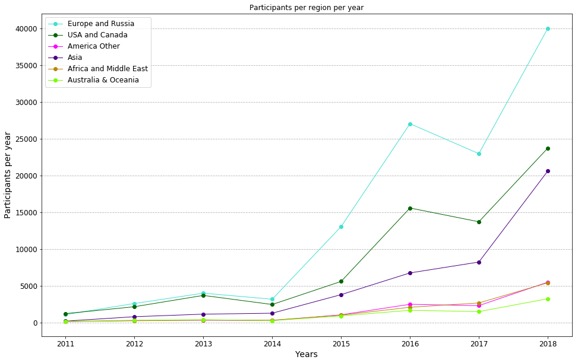

```python
plot_df(participants_per_year,
        columns = ['Europe and Russia','USA and Canada','America Other','Asia','Africa and Middle East','Australia & Oceania'],
        color_dict = region_colors,
        title = 'Participants per region per year',
        ylabel = 'Participants per year')
```

**Observations:**

- The participation in the yearly stack overflow survey has been rising in every region throughout the years, with the exception of 2014 and 2017 for some regions.
- Europe and Russia participate the most, followed by USA and Canada and then Asia. Europe and Russia peak at about 40 000 participants in 2018.
- The participation has been increasing rapidly ever since 2014. Before the yearly increase was much less significant. Especially Europe and Russia have been jumping in participation, going from < 5k in 2014 to ~13k in 2015 to ~27k in 2016 and ~40k in 2018.

### Age

Okay, now let's start comparing the regions in different aspects. Before we start with the actual plotting and analysing, we're going to need to do a bit more prep-work.

We want to compare regions, over time, for a number different manifestations of several different variables. This will be a bit easier if we start to break down the survey dataframes into smaller dataframes.

Let's start by creating regional dataframes for each year only holding the columns that we actually need in the analysis for the given year/region.

```python
# let's create a dict that will hold all years and within the years all regions and
# for every region a dataframe with the variables for the analysis
regional_data = {year: {} for year in survey_years}
```

```python
    columns = []
    for year in survey_years:
        if year != 2017:
            columns.append('Age_Category')
        if year != 2014:
            columns.append('Satisfaction')
        if year in [2015,2016,2017,2018]:
            columns.append('Programming_Hobby')
        if year not in [2014,2015]:
            columns.append('Company_Size')
```

```python
def get_non_lang_columns(year):
    """Get all non-language column labels for the analysis.

    Args:
        year: the year for which to get these columns
    Returns:
        List with column labels of all non-language columns for the analysis.
    """
    columns = ['Age_Category', 'Satisfaction', 'Programming_Hobby', 'Company_Size']

    if year in [2011, 2012, 2013, 2014]:
        columns.remove('Programming_Hobby')
    if year in [2014, 2015]:
        columns.remove('Company_Size')
    if year == 2014:
        columns.remove('Satisfaction')
    if year == 2017:
        columns.remove('Age_Category')

    return columns
```

```python
for year in survey_years:

    columns = get_non_lang_columns(year)
    columns.extend(survey_results[year].columns[survey_results[year].columns.to_series().str.contains('Lang_Tech_Used_')])

    for region in analysis_regions.keys():
        regional_data[year][region] = survey_results[year][survey_results[year]['Region'] == region][columns]
```

```python
regional_data[2016]['Germany'].head()
```

|  | Age_Category | Satisfaction | Programming_Hobby | Company_Size | Lang_Tech_Used_iOS | Lang_Tech_Used_Objective-C | Lang_Tech_Used_Android | Lang_Tech_Used_Arduino / Raspberry Pi | Lang_Tech_Used_AngularJS | Lang_Tech_Used_C | ... | Lang_Tech_Used_Salesforce | Lang_Tech_Used_Scala | Lang_Tech_Used_SharePoint | Lang_Tech_Used_Spark | Lang_Tech_Used_SQL | Lang_Tech_Used_SQL Server | Lang_Tech_Used_Swift | Lang_Tech_Used_Visual Basic | Lang_Tech_Used_Windows Phone | Lang_Tech_Used_WordPress |
| --- | --- | --- | --- | --- | --- | --- | --- | --- | --- | --- | --- | --- | --- | --- | --- | --- | --- | --- | --- | --- | --- |
| 1831 | 1.0 | NaN | 1.0 | NaN | 0 | 0 | 0 | 0 | 1 | 0 | ... | 0 | 0 | 0 | 0 | 1 | 0 | 0 | 0 | 0 | 0 |
| 1832 | 2.0 | satisfied | 1.0 | 3.0 | 1 | 1 | 1 | 0 | 0 | 1 | ... | 0 | 0 | 0 | 0 | 0 | 0 | 1 | 0 | 0 | 0 |
| 1833 | 3.0 | satisfied | 1.0 | 1.0 | 0 | 0 | 0 | 0 | 0 | 0 | ... | 0 | 0 | 0 | 0 | 0 | 0 | 0 | 0 | 0 | 0 |
| 1834 | 1.0 | NaN | NaN | NaN | 0 | 0 | 0 | 0 | 0 | 0 | ... | 0 | 0 | 0 | 0 | 0 | 0 | 0 | 0 | 0 | 0 |
| 1835 | 2.0 | NaN | 1.0 | NaN | 0 | 0 | 1 | 1 | 1 | 1 | ... | 0 | 0 | 0 | 0 | 0 | 0 | 0 | 0 | 0 | 0 |

5 rows × 46 columns

Okay, now we have regional dataframes. Next up is defining a function that takes a certain variable (label) and the manifestation of that variable we want to look at. It should return a dataframe with regions as columns and years as rows for exactly that variable. Since not all variables are included in all years the function should be able to deal with years where that's the case.

```python
def rearrange_regional_data(col, attr, excluded_years):
    """Create a dataframe for a single manifestation of a variable (counting occurences of that manifestation)

    Args:
        col: the variable (column label) to take as basis
        attr: the manifestation of the variable to be analysed
        excluded_years: a list of years excluded from the analysis

    Returns:
        Dataframe with a regional comparison over time
    """
    # prep the data
    data = {year: [] for year in survey_years}
    for year in survey_years:
        for region, r_df in regional_data[year].items():
            if region != 'Other' and year not in excluded_years:
                attribute_count = r_df[col].value_counts().sort_index()
                if attribute_count.shape[0] > 0:
                    data[year].append(attribute_count[attr])
            else:
                data[year].append(0)
    # create a df out of the data
    df = pd.DataFrame(data)
    df.index = regional_data[2018].keys()
    df = df.sort_index()
    df = df.T
    # add a couple extra columns and further aggregate the data
    df = aggregate_regions(df)
    # return the dataframe
    return df
```

Okay, now that we've set up regional dataframes and have a method that can extract the information for a specific manifestation of a variables across regions and years, let's start looking at the age.

Here we have three categories to look at: participants under 25, between 25 and 35 and over 35. Let's create a dataframe for each of these manifestations and then plot them.

```python
under_25 = rearrange_regional_data('Age_Category', 1.0, [2017])
```

```python
between_25_35 = rearrange_regional_data('Age_Category', 2.0, [2017])
```

```python
over_35 = rearrange_regional_data('Age_Category', 3.0, [2017])
```

```python
under_25
```

|  | Africa | America Other | Asia Other | Australia & Oceania | Canada | Europe Other | France | Germany | India | Middle East | Other | Russia | United Kingdom | United States of America | Total | Europe and Russia | USA and Canada | Asia | Africa and Middle East |
| --- | --- | --- | --- | --- | --- | --- | --- | --- | --- | --- | --- | --- | --- | --- | --- | --- | --- | --- | --- |
| 2011 | 12 | 39 | 20 | 25 | 27 | 138 | 10 | 17 | 32 | 23 | 0 | 17 | 63 | 200 | 623 | 245 | 227 | 52 | 35 |
| 2012 | 28 | 89 | 75 | 71 | 91 | 415 | 38 | 66 | 262 | 40 | 0 | 70 | 146 | 430 | 1821 | 735 | 521 | 337 | 68 |
| 2013 | 24 | 88 | 146 | 117 | 138 | 594 | 70 | 145 | 349 | 41 | 0 | 78 | 230 | 711 | 2731 | 1117 | 849 | 495 | 65 |
| 2014 | 40 | 79 | 147 | 70 | 89 | 559 | 64 | 117 | 477 | 60 | 0 | 62 | 181 | 556 | 2501 | 983 | 645 | 624 | 100 |
| 2015 | 135 | 332 | 519 | 270 | 259 | 2339 | 277 | 600 | 1273 | 195 | 0 | 233 | 723 | 1197 | 8352 | 4172 | 1456 | 1792 | 330 |
| 2016 | 326 | 812 | 940 | 478 | 601 | 4790 | 537 | 1100 | 1956 | 306 | 0 | 533 | 1236 | 3240 | 16855 | 8196 | 3841 | 2896 | 632 |
| 2017 | 0 | 0 | 0 | 0 | 0 | 0 | 0 | 0 | 0 | 0 | 0 | 0 | 0 | 0 | 0 | 0 | 0 | 0 | 0 |
| 2018 | 544 | 1015 | 1286 | 565 | 583 | 3580 | 485 | 1185 | 2712 | 357 | 0 | 537 | 1005 | 3017 | 16871 | 6792 | 3600 | 3998 | 901 |

```python
participants_per_year
```

|  | Africa | America Other | Asia Other | Australia & Oceania | Canada | Europe Other | France | Germany | India | Middle East | Other | Russia | United Kingdom | United States of America | Total | Europe and Russia | USA and Canada | Asia | Africa and Middle East |
| --- | --- | --- | --- | --- | --- | --- | --- | --- | --- | --- | --- | --- | --- | --- | --- | --- | --- | --- | --- |
| 2011 | 43 | 125 | 81 | 141 | 156 | 541 | 60 | 106 | 95 | 73 | 0 | 41 | 314 | 1037 | 5626 | 1062 | 1193 | 176 | 116 |
| 2012 | 92 | 258 | 236 | 290 | 348 | 1414 | 135 | 273 | 537 | 124 | 0 | 162 | 589 | 1785 | 12486 | 2573 | 2133 | 773 | 216 |
| 2013 | 115 | 297 | 384 | 364 | 490 | 1984 | 232 | 583 | 737 | 198 | 0 | 241 | 935 | 3181 | 19482 | 3975 | 3671 | 1121 | 313 |
| 2014 | 108 | 251 | 369 | 244 | 306 | 1613 | 198 | 455 | 881 | 195 | 8 | 166 | 721 | 2128 | 15286 | 3153 | 2434 | 1250 | 303 |
| 2015 | 382 | 1031 | 1314 | 882 | 828 | 7227 | 776 | 1976 | 2461 | 599 | 5 | 650 | 2403 | 4745 | 50558 | 13032 | 5573 | 3775 | 981 |
| 2016 | 1003 | 2464 | 2537 | 1650 | 2024 | 15531 | 1626 | 3883 | 4193 | 1055 | 30 | 1419 | 4573 | 13539 | 111054 | 27032 | 15563 | 6730 | 2058 |
| 2017 | 1245 | 2277 | 3012 | 1464 | 2233 | 11782 | 1756 | 4143 | 5197 | 1398 | 151 | 873 | 4402 | 11458 | 102782 | 22956 | 13691 | 8209 | 2643 |
| 2018 | 2753 | 5472 | 6865 | 3220 | 3393 | 21874 | 2572 | 6459 | 13721 | 2630 | 84 | 2869 | 6221 | 20309 | 196884 | 39995 | 23702 | 20586 | 5383 |

```python
print('Number of missing entries in Age_Category')
for year in survey_years:
    if year == 2017:
        continue
    print(str(np.around(1-survey_results[year]['Age_Category'].count()/survey_results[year]['Age_Category'].shape[0],
                        decimals=4)*100)+' %')
```

```
Number of missing entries in Age_Category
2.9899999999999998 %
4.47 %
3.16 %
3.8899999999999997 %
0.98 %
0.54 %
34.68 %
```

Comparing the absolute values makes little sense as there is a large difference in participants per region. We need relative values instead. However, there is a problem when using relative values as well. My first impulse is to use the total of participants in each year and region to calculate the relative values. Yet, this will skew the data, especially in 2018 where almost 35% of the participants did not answer the question. The question is whether we the data of participants who did not answer the question provide any further insights. As we're not trying to find relations between different variables and just looking at the one variable, counting the number of occurences something happens, I don't believe the missing data points are providing any necessary insights. Instead of using the yearly regional total of participants we can instead form a new one: the yearly regional total of participants *who answered the question*. As long as we make sure we use this total in all plots for this variable and make this decision clear in our discussion of the observations, this should be fine.

```python
participants_answered_age = under_25 + between_25_35 + over_35
participants_answered_age
```

|  | Africa | America Other | Asia Other | Australia & Oceania | Canada | Europe Other | France | Germany | India | Middle East | Other | Russia | United Kingdom | United States of America | Total | Europe and Russia | USA and Canada | Asia | Africa and Middle East |
| --- | --- | --- | --- | --- | --- | --- | --- | --- | --- | --- | --- | --- | --- | --- | --- | --- | --- | --- | --- |
| 2011 | 40 | 118 | 77 | 139 | 152 | 520 | 57 | 101 | 91 | 69 | 0 | 40 | 307 | 1018 | 2729 | 1025 | 1170 | 168 | 109 |
| 2012 | 75 | 247 | 215 | 271 | 334 | 1362 | 129 | 256 | 496 | 118 | 0 | 153 | 573 | 1735 | 5964 | 2473 | 2069 | 711 | 193 |
| 2013 | 103 | 290 | 370 | 358 | 474 | 1920 | 226 | 550 | 708 | 192 | 0 | 232 | 916 | 3095 | 9434 | 3844 | 3569 | 1078 | 295 |
| 2014 | 96 | 235 | 343 | 238 | 288 | 1551 | 197 | 440 | 850 | 184 | 0 | 154 | 702 | 2060 | 7338 | 3044 | 2348 | 1193 | 280 |
| 2015 | 369 | 1023 | 1291 | 868 | 814 | 7160 | 771 | 1949 | 2414 | 592 | 0 | 644 | 2379 | 4641 | 24915 | 12903 | 5455 | 3705 | 961 |
| 2016 | 991 | 2456 | 2507 | 1635 | 1999 | 15425 | 1617 | 3842 | 4159 | 1043 | 0 | 1404 | 4540 | 13363 | 54981 | 26828 | 15362 | 6666 | 2034 |
| 2017 | 0 | 0 | 0 | 0 | 0 | 0 | 0 | 0 | 0 | 0 | 0 | 0 | 0 | 0 | 0 | 0 | 0 | 0 | 0 |
| 2018 | 1564 | 3496 | 3606 | 2251 | 2460 | 14764 | 1753 | 4497 | 6599 | 1538 | 0 | 1767 | 4620 | 15601 | 64516 | 27401 | 18061 | 10205 | 3102 |

We're going to plot these dataframes more often. Let's create a function that let's us plot only the aggregate regions, ignoring single countries like germany and the UK for now without having to always type out all the column names every time.

```python
def plot_aggregate_regions(df,
                           title='',
                           yticks=np.linspace(0,1,11),
                           nan_as_zero=True,
                           xlabel='Years',
                           ylabel = '% participants per year',
                           linestyle='-'):
    """Plots the aggregated regions.

    Args:
        df: dataframe holding the data
        title: string; title of the plot
        yticks: list; specification for the Y-ticks; default list from 0-1 for a full representation of the percentages
        nan_as_zero: boolean; whether the NaN values are to be treated as 0s; default: True
        xlabel: string; X-label of the plot; default: 'Years'
        ylabel: string; Y-label of the plot; default: '% participants per year'
        linestyle: string; pyplot linestyle; default: '-'
    """
    if nan_as_zero:
        df[df == 0.0] = np.nan
    plot_df(df,
            columns = ['Europe and Russia',
                       'USA and Canada',
                       'America Other',
                       'Asia',
                       'Africa and Middle East',
                       'Australia & Oceania'],
            color_dict = region_colors,
            title = title,
            xlabel = xlabel,
            ylabel = ylabel,
            yticks = yticks,
           linestyle = linestyle)
```

Alright, let's plot the three age categories and see how the regions compare to each other.

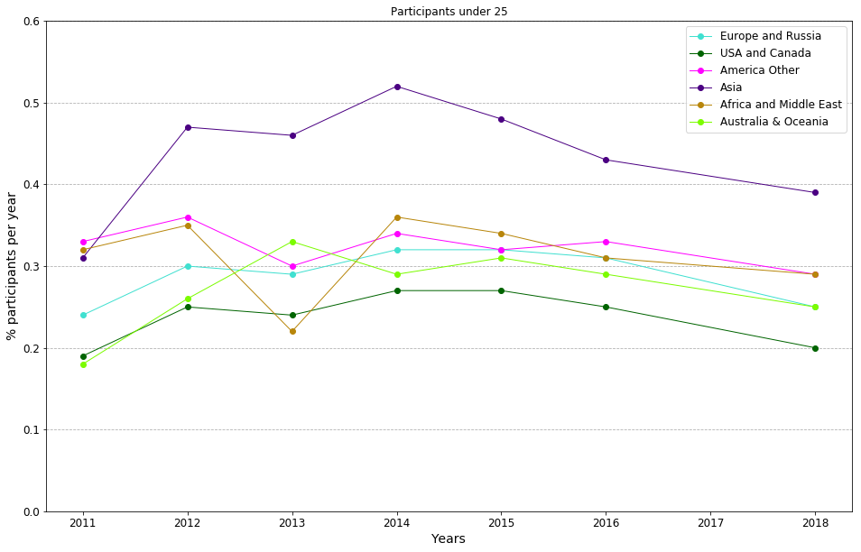

```python
plot_aggregate_regions(np.around(under_25/participants_answered_age, decimals=2),
                       title='Participants under 25',
                       yticks=np.linspace(0,0.6,7))
```

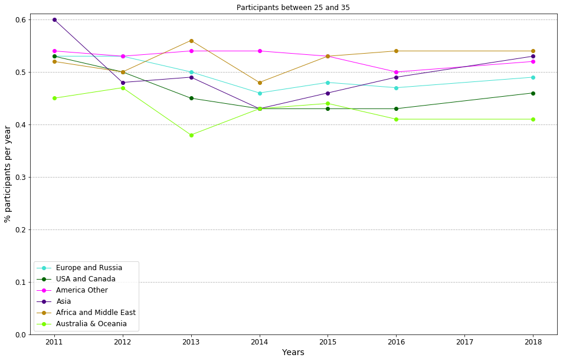

```python
plot_aggregate_regions(np.around(between_25_35/participants_answered_age, decimals=2),
                       title='Participants between 25 and 35',
                       yticks=np.linspace(0,0.6,7))
```

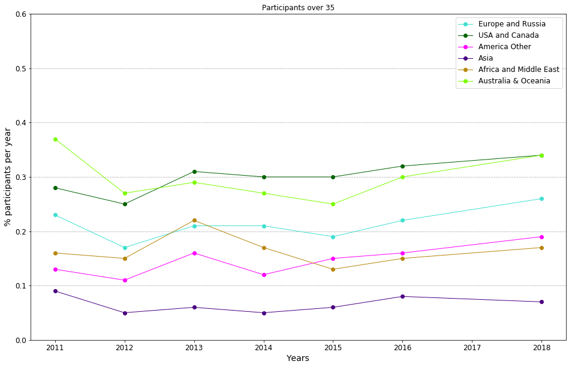

```python
plot_aggregate_regions(np.around(over_35/participants_answered_age, decimals=2),
                       title='Participants over 35',
                       yticks=np.linspace(0,0.6,7))
```

This gives us some insights already. I'll note down my observations in a cell below. One more thing to analyse after seeing these plots is the three age categories in Asia and America, seeing as those to stick out the most being opposite to each other (America high above 35 and Asia high below 25). Let's take a closer look...

```python
def plot_region_age(region):
    """Plots the three age categories of a specific region over time

    Args:
        region: string; which region to plot

    Returns:
        the dataframe with just the region and the three age categories over time
    """
    df = pd.DataFrame()
    df['Under 25'] = under_25[region]
    df['Between 25 and 35'] = between_25_35[region]
    df['Over 35'] = over_35[region]
    df[df == 0.0] = np.nan

    plot_df(df,
           columns = ['Under 25', 'Between 25 and 35', 'Over 35'],
           title = 'Age Categories: ' + region,
           ylabel = 'Age Categories')

    return df
```

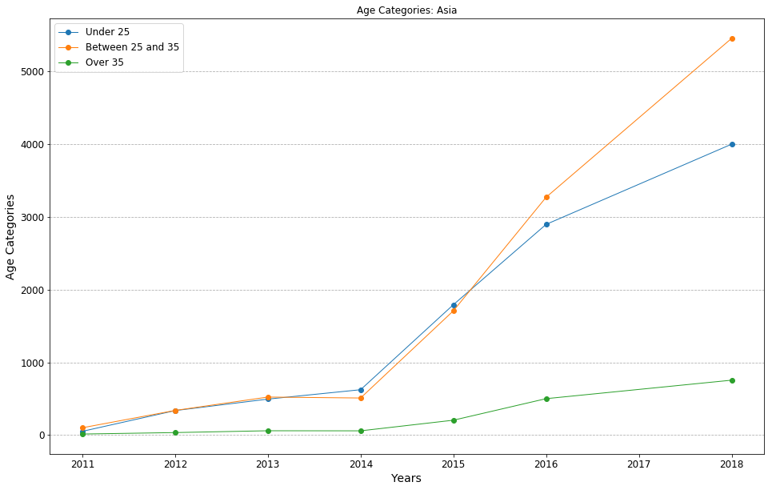

```python
asia_age = plot_region_age('Asia')
```

```python
str(np.around(asia_age['Over 35'].sum() / asia_age.sum().sum(), decimals=4) * 100) + '% of total participants are over 35.'
```

```
'6.87% of total participants are over 35.'
```

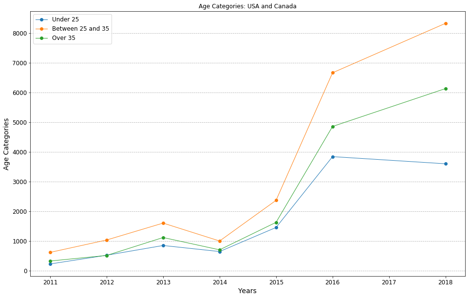

```python
plot_region_age('USA and Canada');
```

### Job Satisfaction

The data about job satisfaction is set up the same way the data about age was, so we can use the same procedure.

```python
regional_data[2011]['Africa']['Satisfaction'].value_counts().sort_index()
```

```
dissatisfied     2
neutral          7
satisfied       22
Name: Satisfaction, dtype: int64
```

```python
satisfied = rearrange_regional_data('Satisfaction', 'satisfied', [2014])
satisfied
```

|  | Africa | America Other | Asia Other | Australia & Oceania | Canada | Europe Other | France | Germany | India | Middle East | Other | Russia | United Kingdom | United States of America | Total | Europe and Russia | USA and Canada | Asia | Africa and Middle East |
| --- | --- | --- | --- | --- | --- | --- | --- | --- | --- | --- | --- | --- | --- | --- | --- | --- | --- | --- | --- |
| 2011 | 22 | 77 | 36 | 88 | 95 | 341 | 42 | 64 | 55 | 40 | 0 | 22 | 203 | 661 | 1746 | 672 | 756 | 91 | 62 |
| 2012 | 33 | 169 | 104 | 165 | 207 | 851 | 82 | 166 | 284 | 66 | 0 | 103 | 379 | 1142 | 3751 | 1581 | 1349 | 388 | 99 |
| 2013 | 56 | 165 | 168 | 196 | 284 | 1006 | 132 | 302 | 385 | 116 | 0 | 122 | 525 | 1899 | 5356 | 2087 | 2183 | 553 | 172 |
| 2014 | 0 | 0 | 0 | 0 | 0 | 0 | 0 | 0 | 0 | 0 | 0 | 0 | 0 | 0 | 0 | 0 | 0 | 0 | 0 |
| 2015 | 168 | 469 | 494 | 472 | 423 | 3351 | 361 | 906 | 1063 | 288 | 0 | 299 | 1269 | 2637 | 12200 | 6186 | 3060 | 1557 | 456 |
| 2016 | 484 | 1359 | 1093 | 905 | 1122 | 8105 | 779 | 1892 | 1929 | 545 | 0 | 692 | 2674 | 7973 | 29552 | 14142 | 9095 | 3022 | 1029 |
| 2017 | 578 | 1498 | 1451 | 898 | 1462 | 7640 | 1057 | 2498 | 2414 | 859 | 0 | 549 | 2955 | 7502 | 31361 | 14699 | 8964 | 3865 | 1437 |
| 2018 | 1018 | 2491 | 2451 | 1640 | 1817 | 11354 | 1334 | 3439 | 5194 | 1179 | 0 | 1317 | 3505 | 11675 | 48414 | 20949 | 13492 | 7645 | 2197 |

```python
neutral_satisfaction = rearrange_regional_data('Satisfaction', 'neutral', [2014])
```

```python
dissatisfied = rearrange_regional_data('Satisfaction', 'dissatisfied', [2014])
```

```python
print('Number of missing entries in Job_Satisfaction')
for year in survey_years:
    if year == 2014:
        continue
    print(str(np.around(1-survey_results[year]['Job_Satisfaction'].count()/survey_results[year]['Job_Satisfaction'].shape[0],
                        decimals=4)*100)+' %')
```

```
Number of missing entries in Job_Satisfaction
9.24 %
12.8 %
21.7 %
38.0 %
28.410000000000004 %
21.43 %
29.92 %
```

Once again the number of missing entries is quite high, often between 20-40%. As we are only comparing counts in one variable and not attempting to find relations to other variables, we can for this analysis ignore the participants that have not answered the question. As a total we will use all the participants that have answered this question. Of course it is important to make this decision clear when discussing the findings later.

```python
participants_answered_satisfaction = satisfied + neutral_satisfaction + dissatisfied
```

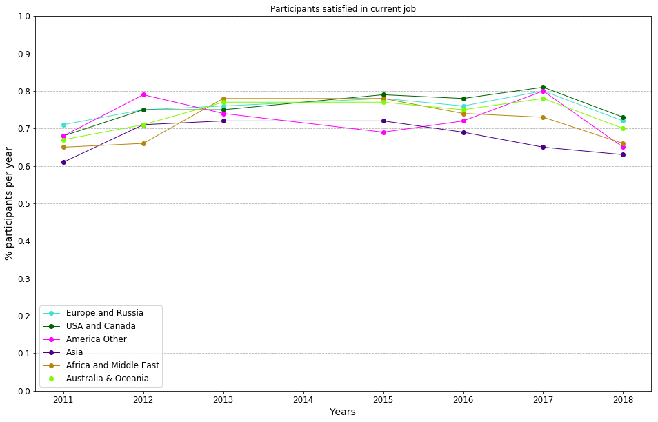

```python
plot_aggregate_regions(np.around(satisfied/participants_answered_satisfaction, decimals=2),
                       title='Participants satisfied in current job')
```

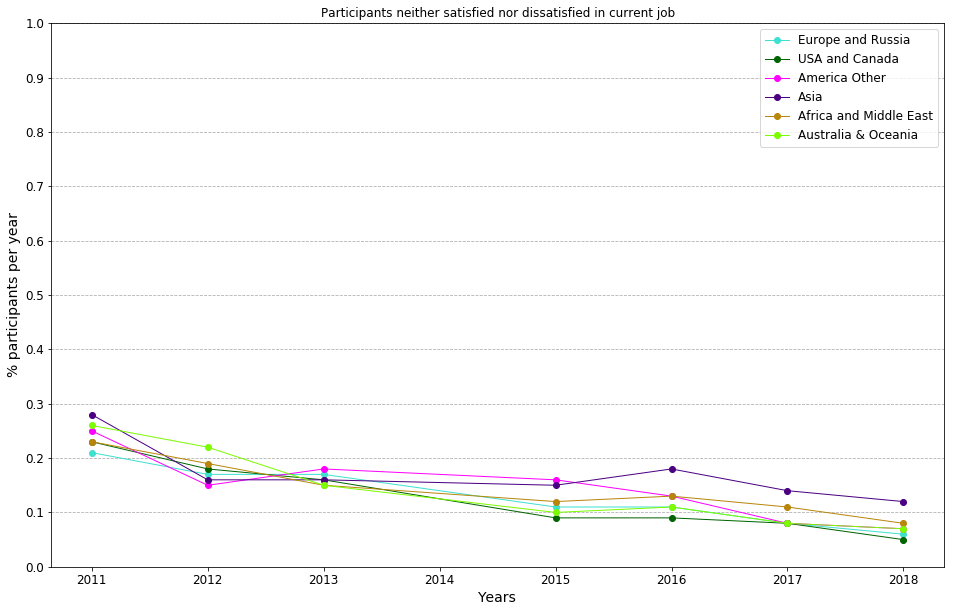

```python
plot_aggregate_regions(np.around(neutral_satisfaction/participants_answered_satisfaction, decimals=2),
                       title='Participants neither satisfied nor dissatisfied in current job')
```

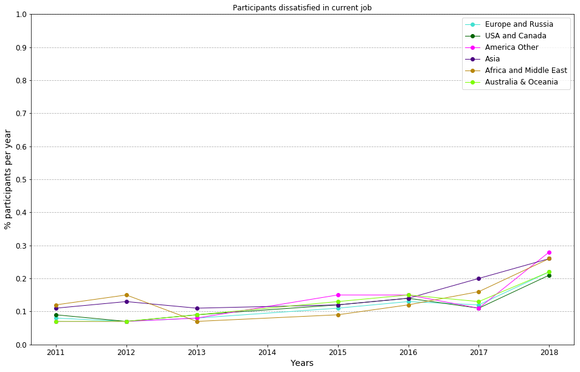

```python
plot_aggregate_regions(np.around(dissatisfied/participants_answered_satisfaction, decimals=2),
                       title='Participants dissatisfied in current job')
```

Interesting, the dissatisfaction appears to be rising across all regions. Let's compare this to the entirety of the participants and see whether we make the same observation.

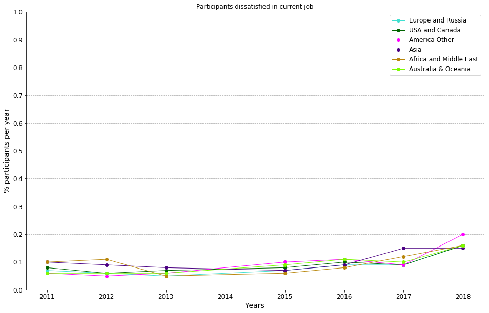

```python
plot_aggregate_regions(np.around(dissatisfied/participants_per_year, decimals=2),
                       title='Participants dissatisfied in current job')
```

### Language Affinities

So, for languages we'll need a different approach. Firstly, let's create a dataframe grouping the languages used count in each region for each year. We'll end up with 8 dataframes for each year, the regions as columns, the languages as rows and the count as cells. Of course, we'll once again have to aggregate the regions.

Since for the languages we can't differentiate between "has not answered" and "answered no" let's make the assumption that anyone who knows a language or tech has answered with yes and all others did not answer the question. This means we'll use the total count of participants per region to calculate the relative values. As the language dataframes are different in shape to the participants_per_region dataframe, we'll have to define a function that calculates the relative values and can't just divide the dataframes directly.

Once we have the language dataframes set up we can analyze them. One interesting insight could be getting the top X languages in each region in each year. Maybe we can also define a number of top languages overall and track them for each region over time, similar to how we did it with the other variables before.

```python
regional_data[2011]['Africa'].drop(columns=get_non_lang_columns(2011)).columns[0]
```

```
'Lang_Tech_Used_Java'
```

```python
regional_data[2011]['Africa'].drop(columns=get_non_lang_columns(2011)).columns[0].split('_')[3]
```

```
'Java'
```

The language columns all have the prefix "Lang_Tech*Used*". It would be nice to only grab the language and ignore the prefix when setting the row labels for our language dataframes.

```python
def parse_lang_label(label):
    """Parses label of the language columns.

    Args:
        label: string; column label with the prefix 'Lang_Tech_Used_'

    Returns:
        the language part of the label as string
    """
    lang = label.split('_')
    lang = lang[3:]
    lang = ' '.join(lang)
    return lang
```

```python
# test
parse_lang_label('Lang_Tech_Used_Windows_Phone')
```

```
'Windows Phone'
```

```python
# set up a dict to hold all the language dataframes
languages_per_region = {year: {} for year in survey_years}

for year in survey_years:
    year_data = {}
    year_langs = [] # list of unique languages in this year; used for setting the index labels later
    # get the non-language column labels in this year
    cols_to_drop = get_non_lang_columns(year)

    # iterate over the regions
    for region, region_df in regional_data[year].items():
        # drop all non-language columns
        lang_df = region_df.drop(columns=cols_to_drop)
        lang_df[lang_df == 0.0] = np.nan # make sure value_counts only counts the participants that used the language
        year_data[region] = []

        # now iterate over all languages of this year
        for col in lang_df.columns:
            # first grab the actual language and drop the unnecessary prefix
            lang = parse_lang_label(col)
            # ignore 'Other' as we want to only look at the main languages
            if lang == 'Other':
                continue
            # add this language to this years languages if it isn't already
            elif lang not in year_langs:
                year_langs.append(lang)
            # add the count of the current language, if the count is 0 add 0
            lang_count = lang_df[col].value_counts()
            if lang_count.shape[0] > 0:
                year_data[region].append(lang_count.iloc[0])
            else:
                year_data[region].append(0)
    # now let's make a dataframe out of the data, update its labels and aggregate the regions
    year_data = pd.DataFrame(year_data)
    year_data.index = year_langs
    year_data = aggregate_regions(year_data)
    # now we can add it to the dictionary of language dataframes
    languages_per_region[year] = year_data
```

```python
# test to see how this looks
languages_per_region[2011]
```

|  | United States of America | Canada | America Other | United Kingdom | Germany | France | Europe Other | India | Asia Other | Russia | Middle East | Africa | Australia & Oceania | Other | Total | Europe and Russia | USA and Canada | Asia | Africa and Middle East |
| --- | --- | --- | --- | --- | --- | --- | --- | --- | --- | --- | --- | --- | --- | --- | --- | --- | --- | --- | --- |
| Java | 307 | 51 | 39 | 77 | 42 | 22 | 190 | 22 | 24 | 6 | 23 | 10 | 48 | 0 | 861 | 337 | 358 | 46 | 33 |
| JavaScript | 551 | 81 | 70 | 169 | 47 | 29 | 261 | 35 | 37 | 11 | 31 | 19 | 78 | 0 | 1419 | 517 | 632 | 72 | 50 |
| CSS | 533 | 80 | 60 | 160 | 54 | 27 | 248 | 24 | 36 | 11 | 31 | 16 | 76 | 0 | 1356 | 500 | 613 | 60 | 47 |
| PHP | 284 | 43 | 36 | 93 | 39 | 15 | 171 | 10 | 28 | 4 | 13 | 14 | 38 | 0 | 788 | 322 | 327 | 38 | 27 |
| Python | 204 | 32 | 34 | 64 | 29 | 14 | 121 | 9 | 12 | 6 | 14 | 8 | 28 | 0 | 575 | 234 | 236 | 21 | 22 |
| Ruby | 122 | 20 | 9 | 27 | 19 | 4 | 53 | 5 | 5 | 3 | 5 | 0 | 13 | 0 | 285 | 106 | 142 | 10 | 5 |
| SQL | 650 | 101 | 74 | 181 | 51 | 25 | 303 | 29 | 36 | 13 | 34 | 25 | 91 | 0 | 1613 | 573 | 751 | 65 | 59 |
| C# | 543 | 75 | 53 | 159 | 44 | 25 | 232 | 39 | 38 | 19 | 34 | 19 | 72 | 0 | 1352 | 479 | 618 | 77 | 53 |
| C++ | 265 | 49 | 28 | 74 | 32 | 16 | 142 | 20 | 20 | 13 | 32 | 7 | 42 | 0 | 740 | 277 | 314 | 40 | 39 |
| C | 273 | 47 | 41 | 69 | 27 | 14 | 141 | 23 | 24 | 8 | 27 | 5 | 42 | 0 | 741 | 259 | 320 | 47 | 32 |
| Perl | 136 | 19 | 4 | 27 | 8 | 3 | 45 | 5 | 7 | 5 | 7 | 1 | 17 | 0 | 284 | 88 | 155 | 12 | 8 |
| None | 12 | 1 | 1 | 1 | 0 | 0 | 1 | 1 | 1 | 0 | 1 | 1 | 0 | 0 | 20 | 2 | 13 | 2 | 2 |

```python
participants_per_year
```

|  | Africa | America Other | Asia Other | Australia & Oceania | Canada | Europe Other | France | Germany | India | Middle East | Other | Russia | United Kingdom | United States of America | Total | Europe and Russia | USA and Canada | Asia | Africa and Middle East |
| --- | --- | --- | --- | --- | --- | --- | --- | --- | --- | --- | --- | --- | --- | --- | --- | --- | --- | --- | --- |
| 2011 | 43 | 125 | 81 | 141 | 156 | 541 | 60 | 106 | 95 | 73 | 0 | 41 | 314 | 1037 | 5626 | 1062 | 1193 | 176 | 116 |
| 2012 | 92 | 258 | 236 | 290 | 348 | 1414 | 135 | 273 | 537 | 124 | 0 | 162 | 589 | 1785 | 12486 | 2573 | 2133 | 773 | 216 |
| 2013 | 115 | 297 | 384 | 364 | 490 | 1984 | 232 | 583 | 737 | 198 | 0 | 241 | 935 | 3181 | 19482 | 3975 | 3671 | 1121 | 313 |
| 2014 | 108 | 251 | 369 | 244 | 306 | 1613 | 198 | 455 | 881 | 195 | 8 | 166 | 721 | 2128 | 15286 | 3153 | 2434 | 1250 | 303 |
| 2015 | 382 | 1031 | 1314 | 882 | 828 | 7227 | 776 | 1976 | 2461 | 599 | 5 | 650 | 2403 | 4745 | 50558 | 13032 | 5573 | 3775 | 981 |
| 2016 | 1003 | 2464 | 2537 | 1650 | 2024 | 15531 | 1626 | 3883 | 4193 | 1055 | 30 | 1419 | 4573 | 13539 | 111054 | 27032 | 15563 | 6730 | 2058 |
| 2017 | 1245 | 2277 | 3012 | 1464 | 2233 | 11782 | 1756 | 4143 | 5197 | 1398 | 151 | 873 | 4402 | 11458 | 102782 | 22956 | 13691 | 8209 | 2643 |
| 2018 | 2753 | 5472 | 6865 | 3220 | 3393 | 21874 | 2572 | 6459 | 13721 | 2630 | 84 | 2869 | 6221 | 20309 | 196884 | 39995 | 23702 | 20586 | 5383 |

```python
# initialize a dict holding all language dataframes with relative counts
lang_relative = {year: {} for year in survey_years}

# iterate over years and regions
for year in survey_years:
    year_data = {}
    for region in participants_per_year.columns:
        region_total = participants_per_year[region][year] # grab the total of participants in this year and region
        # now divide the regional language counts by the total regional participants in this year
        year_data[region] = np.around(languages_per_region[year][region] / region_total, decimals=2)
    # create the dataframe from the data and add it to the dict
    lang_relative[year] = pd.DataFrame(year_data)
```

```python
# test
lang_relative[2011]
```

|  | Africa | America Other | Asia Other | Australia & Oceania | Canada | Europe Other | France | Germany | India | Middle East | Other | Russia | United Kingdom | United States of America | Total | Europe and Russia | USA and Canada | Asia | Africa and Middle East |
| --- | --- | --- | --- | --- | --- | --- | --- | --- | --- | --- | --- | --- | --- | --- | --- | --- | --- | --- | --- |
| Java | 0.23 | 0.31 | 0.30 | 0.34 | 0.33 | 0.35 | 0.37 | 0.40 | 0.23 | 0.32 | NaN | 0.15 | 0.25 | 0.30 | 0.15 | 0.32 | 0.30 | 0.26 | 0.28 |
| JavaScript | 0.44 | 0.56 | 0.46 | 0.55 | 0.52 | 0.48 | 0.48 | 0.44 | 0.37 | 0.42 | NaN | 0.27 | 0.54 | 0.53 | 0.25 | 0.49 | 0.53 | 0.41 | 0.43 |
| CSS | 0.37 | 0.48 | 0.44 | 0.54 | 0.51 | 0.46 | 0.45 | 0.51 | 0.25 | 0.42 | NaN | 0.27 | 0.51 | 0.51 | 0.24 | 0.47 | 0.51 | 0.34 | 0.41 |
| PHP | 0.33 | 0.29 | 0.35 | 0.27 | 0.28 | 0.32 | 0.25 | 0.37 | 0.11 | 0.18 | NaN | 0.10 | 0.30 | 0.27 | 0.14 | 0.30 | 0.27 | 0.22 | 0.23 |
| Python | 0.19 | 0.27 | 0.15 | 0.20 | 0.21 | 0.22 | 0.23 | 0.27 | 0.09 | 0.19 | NaN | 0.15 | 0.20 | 0.20 | 0.10 | 0.22 | 0.20 | 0.12 | 0.19 |
| Ruby | 0.00 | 0.07 | 0.06 | 0.09 | 0.13 | 0.10 | 0.07 | 0.18 | 0.05 | 0.07 | NaN | 0.07 | 0.09 | 0.12 | 0.05 | 0.10 | 0.12 | 0.06 | 0.04 |
| SQL | 0.58 | 0.59 | 0.44 | 0.65 | 0.65 | 0.56 | 0.42 | 0.48 | 0.31 | 0.47 | NaN | 0.32 | 0.58 | 0.63 | 0.29 | 0.54 | 0.63 | 0.37 | 0.51 |
| C# | 0.44 | 0.42 | 0.47 | 0.51 | 0.48 | 0.43 | 0.42 | 0.42 | 0.41 | 0.47 | NaN | 0.46 | 0.51 | 0.52 | 0.24 | 0.45 | 0.52 | 0.44 | 0.46 |
| C++ | 0.16 | 0.22 | 0.25 | 0.30 | 0.31 | 0.26 | 0.27 | 0.30 | 0.21 | 0.44 | NaN | 0.32 | 0.24 | 0.26 | 0.13 | 0.26 | 0.26 | 0.23 | 0.34 |
| C | 0.12 | 0.33 | 0.30 | 0.30 | 0.30 | 0.26 | 0.23 | 0.25 | 0.24 | 0.37 | NaN | 0.20 | 0.22 | 0.26 | 0.13 | 0.24 | 0.27 | 0.27 | 0.28 |
| Perl | 0.02 | 0.03 | 0.09 | 0.12 | 0.12 | 0.08 | 0.05 | 0.08 | 0.05 | 0.10 | NaN | 0.12 | 0.09 | 0.13 | 0.05 | 0.08 | 0.13 | 0.07 | 0.07 |
| None | 0.02 | 0.01 | 0.01 | 0.00 | 0.01 | 0.00 | 0.00 | 0.00 | 0.01 | 0.01 | NaN | 0.00 | 0.00 | 0.01 | 0.00 | 0.00 | 0.01 | 0.01 | 0.02 |

Let's plot the regional counts for each language in each year.

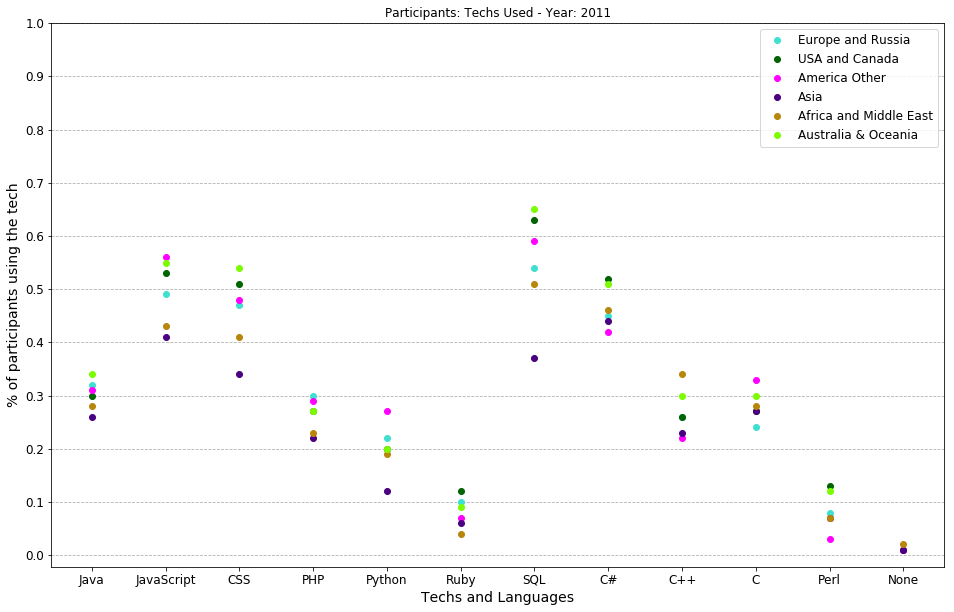

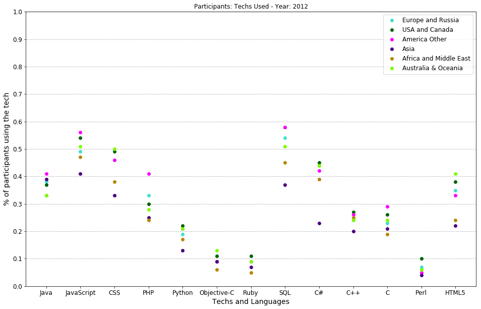

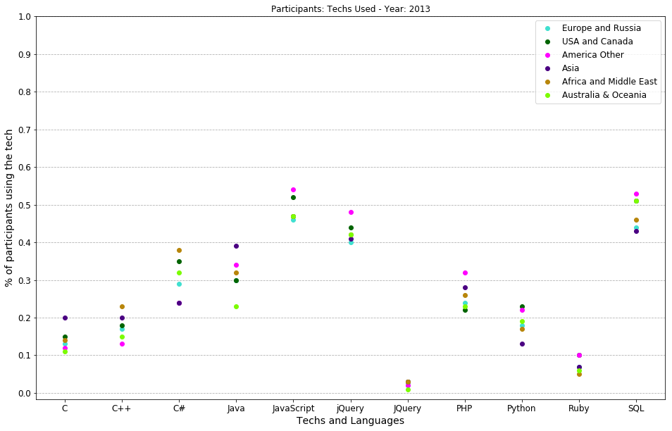

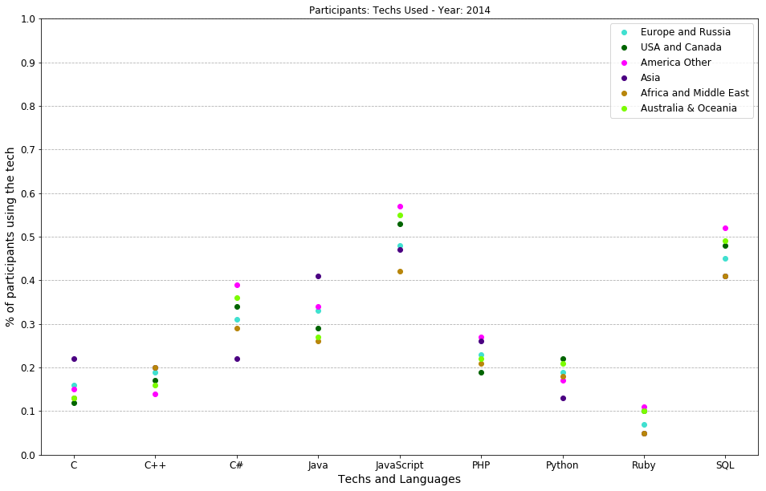

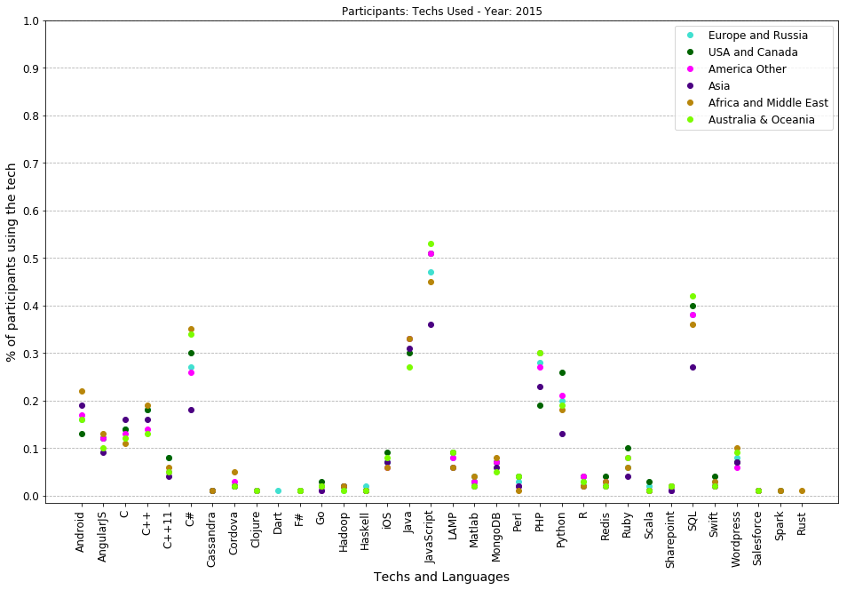

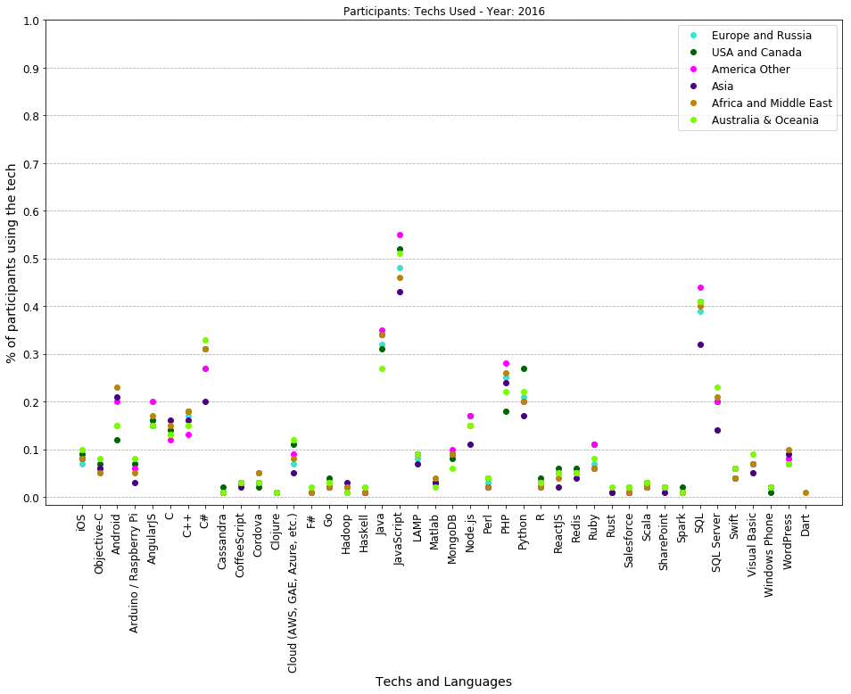

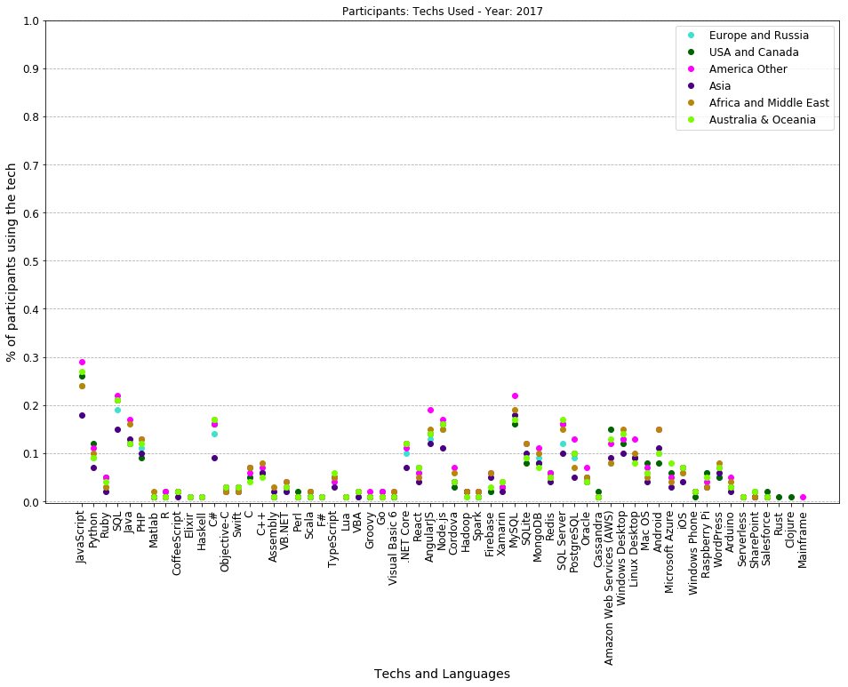

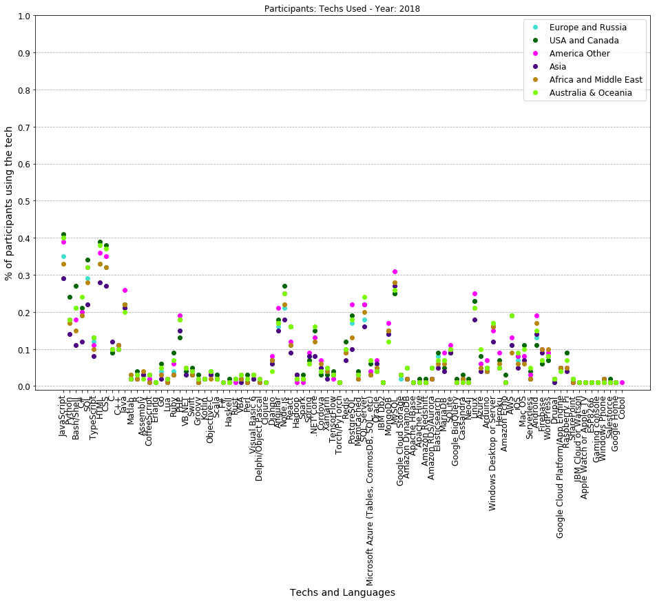

```python
for year in survey_years:
    plot_aggregate_regions(lang_relative[year],
                           title='Participants: Techs Used - Year: ' + str(year),
                           xlabel='Techs and Languages',
                           ylabel='% of participants using the tech',
                           linestyle='')
```

Okay, now let's get the top ten techs of each year across all regions.

```python
lang_relative[2011]['Africa'].nlargest().index
```

```
Index(['SQL', 'JavaScript', 'C#', 'CSS', 'PHP'], dtype='object')
```

```python
for year in survey_years:
    print('Top 10 techs of {}: {}'.format(year,list(lang_relative[year]['Total'].nlargest(n=15).index)))
```

```
Top 10 techs of 2011: ['SQL', 'JavaScript', 'CSS', 'C#', 'Java', 'PHP', 'C++', 'C', 'Python', 'Ruby', 'Perl']
Top 10 techs of 2012: ['SQL', 'JavaScript', 'CSS', 'C#', 'Java', 'HTML5', 'PHP', 'C++', 'C', 'Python', 'Objective-C', 'Ruby', 'Perl']
Top 10 techs of 2013: ['JavaScript', 'SQL', 'jQuery', 'C#', 'Java', 'PHP', 'Python', 'C++', 'C', 'Ruby', 'JQuery']
Top 10 techs of 2014: ['JavaScript', 'SQL', 'C#', 'Java', 'PHP', 'Python', 'C++', 'C', 'Ruby']
Top 10 techs of 2015: ['JavaScript', 'SQL', 'Java', 'C#', 'PHP', 'Python', 'C++', 'Android', 'C', 'AngularJS', 'C++11', 'iOS', 'LAMP', 'Wordpress', 'MongoDB']
Top 10 techs of 2016: ['JavaScript', 'SQL', 'Java', 'C#', 'PHP', 'Python', 'C++', 'Android', 'AngularJS', 'Node.js', 'SQL Server', 'C', 'iOS', 'Cloud (AWS, GAE, Azure, etc.)', 'LAMP']
Top 10 techs of 2017: ['JavaScript', 'SQL', 'MySQL', 'C#', 'AngularJS', 'Node.js', 'SQL Server', 'Java', 'Windows Desktop', 'Python', 'PHP', '.NET Core', 'SQLite', 'Amazon Web Services (AWS)', 'Linux Desktop']
Top 10 techs of 2018: ['JavaScript', 'HTML', 'CSS', 'SQL', 'MySQL', 'Java', 'Node.js', 'Linux', 'Bash/Shell', 'Python', 'C#', 'SQL Server', 'PHP', 'Angular', 'PostgreSQL']
```

```python
for region in ['Europe and Russia',
               'USA and Canada',
               'America Other',
               'Asia',
               'Africa and Middle East',
               'Australia & Oceania',
               'Total']:
    print('Region: {}'.format(region))
    print('='*50)
    for year in survey_years:
        print('Top 3 languages of the year: {}'.format(year))
        print('-'*50)
        print('{}'.format(list(lang_relative[year]['Total'].nlargest(n=3).index)))
        print()
```

```
Region: Europe and Russia
==================================================
Top 3 languages of the year: 2011
--------------------------------------------------
['SQL', 'JavaScript', 'CSS']

Top 3 languages of the year: 2012
--------------------------------------------------
['SQL', 'JavaScript', 'CSS']

Top 3 languages of the year: 2013
--------------------------------------------------
['JavaScript', 'SQL', 'jQuery']

Top 3 languages of the year: 2014
--------------------------------------------------
['JavaScript', 'SQL', 'C#']

Top 3 languages of the year: 2015
--------------------------------------------------
['JavaScript', 'SQL', 'Java']

Top 3 languages of the year: 2016
--------------------------------------------------
['JavaScript', 'SQL', 'Java']

Top 3 languages of the year: 2017
--------------------------------------------------
['JavaScript', 'SQL', 'MySQL']

Top 3 languages of the year: 2018
--------------------------------------------------
['JavaScript', 'HTML', 'CSS']

Region: USA and Canada
==================================================
Top 3 languages of the year: 2011
--------------------------------------------------
['SQL', 'JavaScript', 'CSS']

```

[output cut: 182 more lines]

```
Top 3 languages of the year: 2015
--------------------------------------------------
['JavaScript', 'SQL', 'Java']

Top 3 languages of the year: 2016
--------------------------------------------------
['JavaScript', 'SQL', 'Java']

Top 3 languages of the year: 2017
--------------------------------------------------
['JavaScript', 'SQL', 'MySQL']

Top 3 languages of the year: 2018
--------------------------------------------------
['JavaScript', 'HTML', 'CSS']
```

Ignoring platforms and techs, the top 10 languages/frameworks to look at are:

Javascript, SQL, Java, C#, Python, PHP, C++, NodeJS (=NodeJS, Node.js), C, AngularJS (=AngularJS, Angular)

```python
for year in survey_years:
    if 'Node.js' in lang_relative[year].index:
        lang_relative[year].rename(index={'Node.js':'NodeJS'}, inplace=True)
        print('Updated Node.js in {}'.format(year))
    if 'Angular' in lang_relative[year].index:
        lang_relative[year].rename(index={'Angular':'AngularJS'}, inplace=True)
        print('Updated Angular in {}'.format(year))
```

```
Updated Node.js in 2016
Updated Node.js in 2017
Updated Node.js in 2018
Updated Angular in 2018
```

```python
lang_relative[2018]['Africa']['AngularJS']
```

```
0.18
```

```python
top_languages = ['JavaScript', 'SQL', 'Java', 'C#', 'Python', 'PHP', 'C++', 'NodeJS', 'C', 'AngularJS']
```

```python
lang_relative[2011].T.shape
```

```
(19, 12)
```

Now, let's create a dataframe for each of the top 10 total languages, tracking its usage across regions and years. As usual we are placing the dataframes in a dictionary, to keep things organized.

```python
top_lang_data = {lang: {} for lang in top_languages}

for year in survey_years:
    for lang in top_languages:
        if lang in lang_relative[year].index:
            top_lang_data[lang][year] = lang_relative[year].T[lang]
        else:
            top_lang_data[lang][year] = np.zeros(lang_relative[year].T.shape[0])
```

```python
for lang in top_languages:
    top_lang_data[lang] = pd.DataFrame(top_lang_data[lang]).T
```

```python
top_lang_data['JavaScript']
```

|  | Africa | America Other | Asia Other | Australia & Oceania | Canada | Europe Other | France | Germany | India | Middle East | Other | Russia | United Kingdom | United States of America | Total | Europe and Russia | USA and Canada | Asia | Africa and Middle East |
| --- | --- | --- | --- | --- | --- | --- | --- | --- | --- | --- | --- | --- | --- | --- | --- | --- | --- | --- | --- |
| 2011 | 0.44 | 0.56 | 0.46 | 0.55 | 0.52 | 0.48 | 0.48 | 0.44 | 0.37 | 0.42 | NaN | 0.27 | 0.54 | 0.53 | 0.25 | 0.49 | 0.53 | 0.41 | 0.43 |
| 2012 | 0.39 | 0.56 | 0.46 | 0.51 | 0.54 | 0.49 | 0.47 | 0.41 | 0.39 | 0.53 | NaN | 0.35 | 0.55 | 0.55 | 0.25 | 0.49 | 0.54 | 0.41 | 0.47 |
| 2013 | 0.50 | 0.54 | 0.46 | 0.47 | 0.49 | 0.46 | 0.47 | 0.38 | 0.48 | 0.46 | NaN | 0.39 | 0.51 | 0.52 | 0.24 | 0.46 | 0.52 | 0.47 | 0.47 |
| 2014 | 0.43 | 0.57 | 0.46 | 0.55 | 0.48 | 0.48 | 0.53 | 0.38 | 0.48 | 0.42 | 0.62 | 0.43 | 0.53 | 0.53 | 0.25 | 0.48 | 0.53 | 0.47 | 0.42 |
| 2015 | 0.47 | 0.51 | 0.39 | 0.53 | 0.50 | 0.48 | 0.47 | 0.42 | 0.35 | 0.44 | 0.40 | 0.42 | 0.51 | 0.51 | 0.23 | 0.47 | 0.51 | 0.36 | 0.45 |
| 2016 | 0.50 | 0.55 | 0.44 | 0.51 | 0.51 | 0.49 | 0.47 | 0.44 | 0.42 | 0.42 | 0.50 | 0.42 | 0.53 | 0.52 | 0.25 | 0.48 | 0.52 | 0.43 | 0.46 |
| 2017 | 0.25 | 0.29 | 0.21 | 0.27 | 0.27 | 0.24 | 0.22 | 0.21 | 0.17 | 0.24 | 0.11 | 0.16 | 0.26 | 0.26 | 0.12 | 0.24 | 0.26 | 0.18 | 0.24 |
| 2018 | 0.34 | 0.39 | 0.32 | 0.40 | 0.39 | 0.36 | 0.36 | 0.32 | 0.27 | 0.32 | 0.27 | 0.27 | 0.39 | 0.42 | 0.18 | 0.35 | 0.41 | 0.29 | 0.33 |

And now let's plot each of these language dataframes to look at how the language usage developed over time for each region.

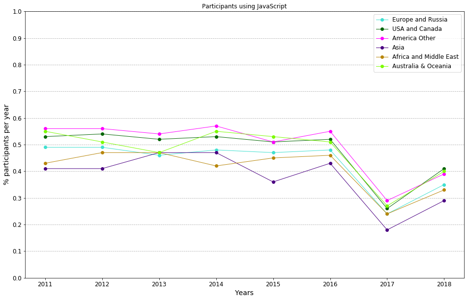

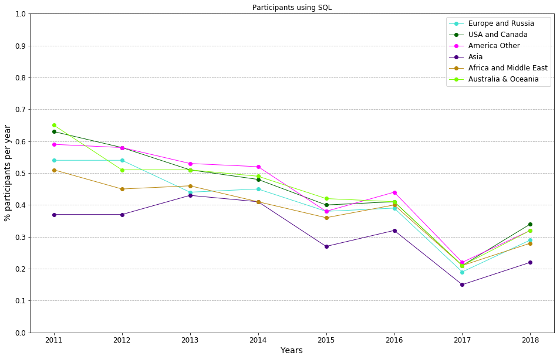

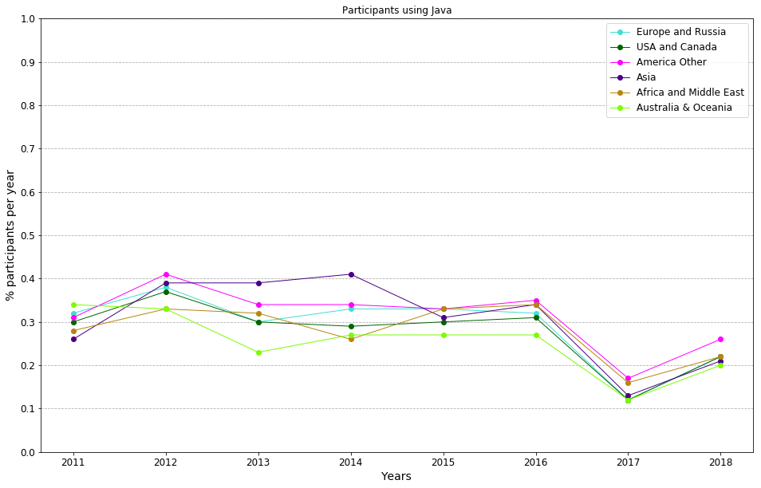

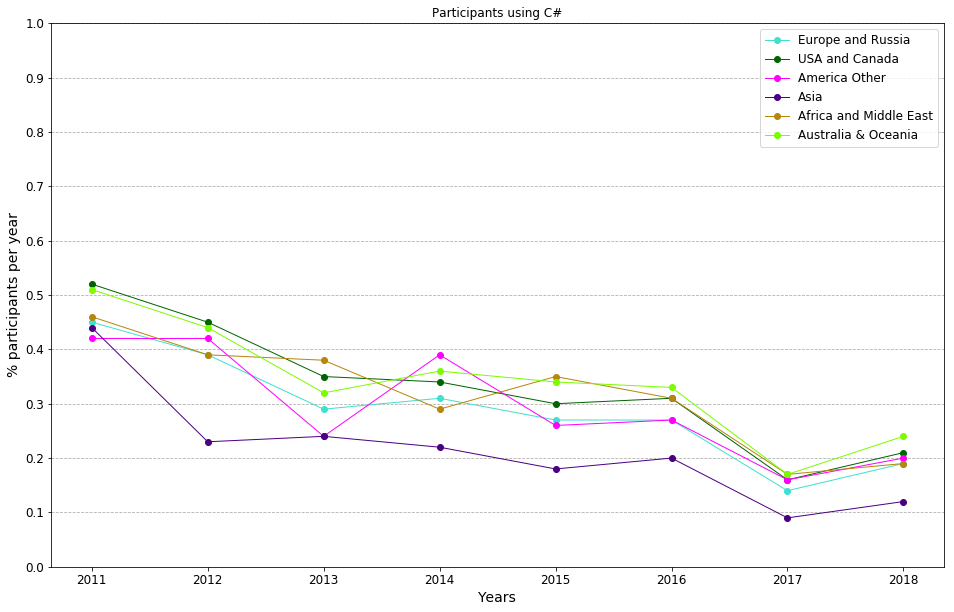

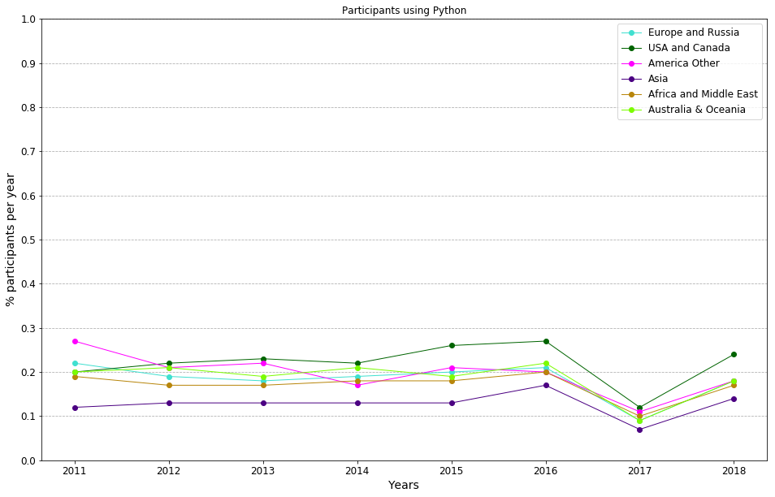

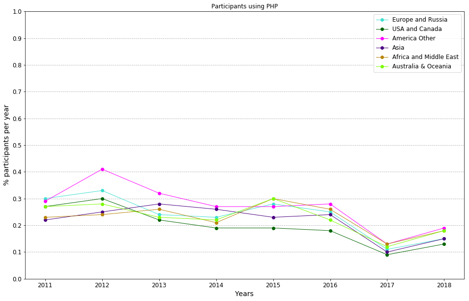

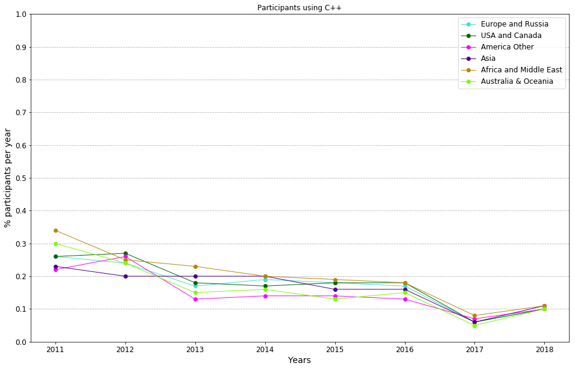

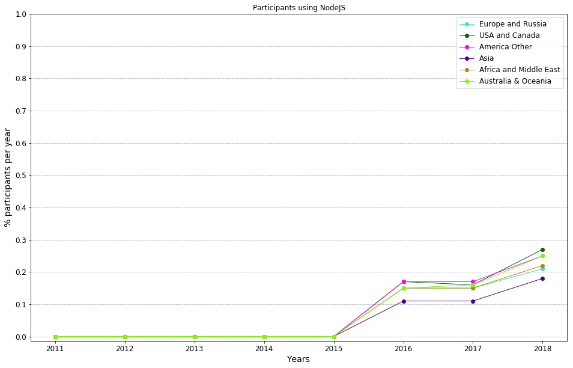

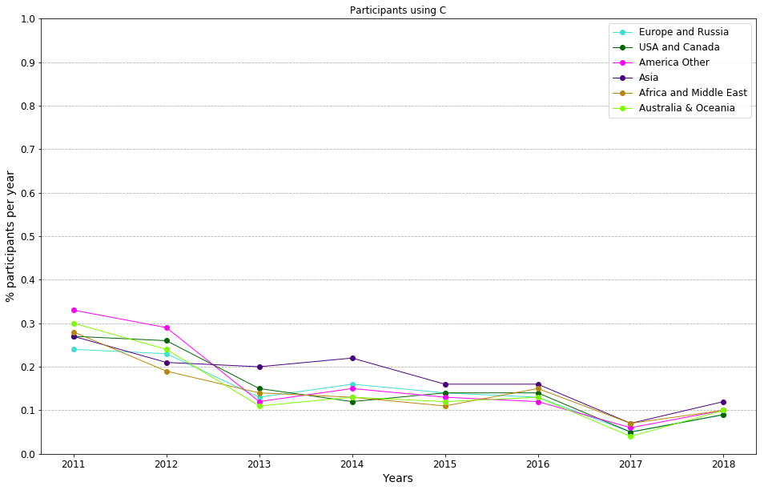

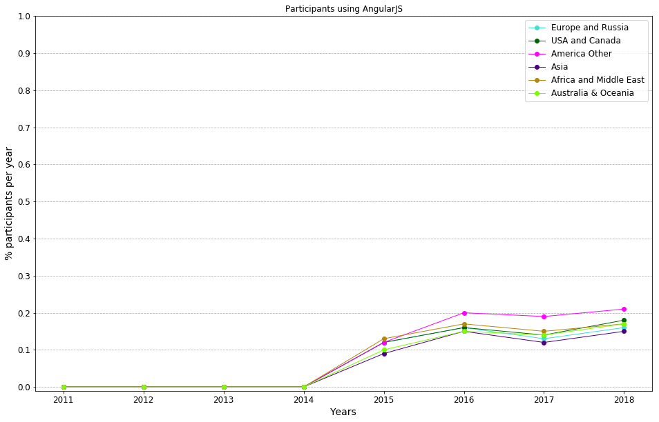

```python
for lang in top_languages:
    plot_aggregate_regions(top_lang_data[lang].fillna(0), nan_as_zero=False, title='Participants using '+lang)
```

Let's look at a couple of specific countries and see whether there are some more insights possible.